# The evolutionary conflicts of inbreeding

Author

Thomas Keaney, Arvid Agren and Hanna Kokko

# Load packages

```r
# for tidy style coding and plotting

library(tidyverse)
library(vroom) # to read lots of csv files at once

# making ggplot more powerful

library(MetBrewer) # for colour palettes based upon artwork housed at the MET
library(MoMAColors) # for colour palettes based upon artwork housed at MoMA
library(PNWColors) # for colour palettes
library(stickylabeller) # labelling facets with strings in ggplot
library(geomtextpath) # for curved plot annotations
library(ggtext) # for markdown syntax in plot labels
library(patchwork) # for patching plots together
library(ggnewscale) # to reset scales in plots, allowing multiple fill arguments in ggplot

# for going parallel locally
library(parallel)

# for computation speed checks

#library(profvis) # breakdown of complex functions
library(bench) # individual functions

# for a neat report of the system environment
library(report)
```

# Plotting results from the inclusive fitness model

We find the inbreeding depression tolerance thresholds with strict polygyny are

$$\begin{align}
\delta_{i, \mathrm{f}}^* = \frac{r_{\mathrm{fm}}c_{i, \mathrm{m}} + r_{\mathrm{fm}}c_{i, \mathrm{m}}F_\mathrm{m}}{c_{i, \mathrm{f}} + c_{i, \mathrm{f}}F_\mathrm{f} + r_{\mathrm{fm}}c_{i, \mathrm{m}}F_\mathrm{m} + r_{\mathrm{fm}}c_{i, \mathrm{m}}} \label{female_new_threshold}
\end{align}$$
$$\begin{align}
\delta_{i, \mathrm{m}}^* = \frac{c_{i, \mathrm{m}} + c_{i, \mathrm{m}}F_\mathrm{m}}{r_{\mathrm{mf}}c_{i, \mathrm{f}} + r_{\mathrm{mf}}c_{i, \mathrm{f}}F_\mathrm{f} + c_{i, \mathrm{m}} + c_{i, \mathrm{m}}F_\mathrm{m}}. \label{male_new_threshold}
\end{align}$$

where $r_{\mathrm{fm}}$ is the genomic region specific relatedness coefficient between a female and interacting male, $r_{\mathrm{mf}}$ is the genomic region specific relatedness coefficient between a male and interacting female, $c_{i, \mathrm{m}}$ and $c_{i, \mathrm{f}}$ are the total juvenile class reproductive values of males and females, respectively, and $F_\mathrm{f}$ and $F_\mathrm{m}$ account for sex-specific ploidy dilution. See main text for more details.

We use these equations to produce Figure 1.

## Building Figure 1

Let’s plot the conflict zones between the sexes, for each genomic region.

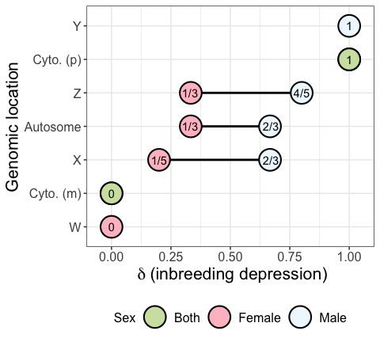

```r
figure_1_thresholds <-
  expand_grid(r_fm = c(0, 1/4, 1/2, 1),
              r_mf = c(0, 1/4, 1/2, 1),
              c_m = c(0, 0.5, 1),
              c_f = c(0, 0.5, 1),
              F_m = c(0, 1),
              F_f = c(0, 1),
              Sex = c("A. Female within-organism conflict",
                      "B. Male within-organism conflict")) %>%
  mutate(D = case_when(Sex == "A. Female within-organism conflict" ~ (r_fm*c_m*F_m + r_fm*c_m) /
                         (r_fm*c_m*F_m + r_fm*c_m + c_f*F_f + c_f),
                       Sex == "B. Male within-organism conflict" ~ (c_m + c_m*F_m) /
                         (c_m + c_m*F_m + r_mf*c_f + r_mf*c_f*F_f))) %>%
  mutate(Case = case_when(c_m == 1 & c_f == 1 & F_f == 0 & F_m == 0 & r_fm == 1/2 & r_mf == 1/2 ~ "Autosome",
                          c_m == 0.5 & c_f == 1 & F_f == 0 & F_m == 1 & r_fm == 1/4 & r_mf == 1/2 ~ "X",
                          c_m == 1 & c_f == 0.5 & F_f == 1 & F_m == 0 & r_fm == 1/2 & r_mf == 1/4 ~ "Z",
                          c_m == 0 & c_f == 1 & F_m == 0 & F_f == 1 & r_fm == 0 & r_mf == 0 &
                            Sex == "A. Female within-organism conflict" ~ "W",
                          c_m == 1 & c_f == 0 & F_m == 1 & F_f == 0 & r_fm == 0 & r_mf == 0 &
                            Sex == "B. Male within-organism conflict" ~ "Y",
                          c_m == 0 & c_f == 1 & F_m == 1 & F_f == 1 & r_fm == 1 & r_mf == 1  ~ "Cyto. (m)",
                          c_m == 1 & c_f == 0 & F_m == 1 & F_f == 1 & r_fm == 1 & r_mf == 1 ~ "Cyto. (p)")) |>
  # prune to relevant biological cases
  filter(!is.na(Case))


conflict_plot <-
  figure_1_thresholds %>%
  mutate(Case = case_when(str_detect(Case, "W") ~ "W",
                          str_detect(Case, "Y") ~ "Y",
                          .default = Case),
         Sex = case_when(str_detect(Case, "Cyto") ~ "Both",
                         str_detect(Sex,"Female") ~ "Female",
                         str_detect(Sex, "Male") ~ "Male"),
         D = case_when(str_detect(Case, "p") ~ D - 0.000001,
                       str_detect(Case, "m") ~ D + 0.000001,
                       .default = D)) %>%
  ggplot(aes(x = D, y = reorder(Case, D), group = Case)) +
  geom_line(size = 1) +
  geom_point(aes(fill = Sex), shape = 21, size = 9, stroke = 1.1) +
  scale_fill_manual(values = c("#d0e2af", "pink", "aliceblue")) +
  annotate("text", x = 0, y = 1, label = "0") +
  annotate("text", x = 0, y = 2, label = "0") +
  annotate("text", x = 0.67, y = 3, label = "2/3") +
  annotate("text", x = 0.2, y = 3, label = "1/5") +
  annotate("text", x = 0.67, y = 4, label = "2/3") +
  annotate("text", x = 0.33, y = 4, label = "1/3") +
  annotate("text", x = 0.8, y = 5, label = "4/5") +
  annotate("text", x = 0.33, y = 5, label = "1/3") +
  annotate("text", x = 1, y = 6, label = "1") +
  annotate("text", x = 1, y = 7, label = "1") +
  labs(x = ~delta~'(inbreeding depression)',
       y = "Genomic location") +
   scale_x_continuous(limits = c(-0.05, 1.05)) +
  theme_bw() +
  theme(axis.title = element_text(size = 16),
        axis.text = element_text(size = 12),
        legend.position = "bottom",
        legend.title = element_text(size = 12),
        legend.text = element_text(size = 12),
        plot.title = element_text(hjust = 0.5, size = 14))

conflict_plot
```

**Figure 1**. Within-organism conflict over inbreeding acceptance. Coloured circles indicate the severity of inbreeding depression below which inbreeding increases the inclusive fitness of genes in a particular genomic region, when mating is between full-siblings. Pink circles show $\delta_{i,\mathrm{f}}^*$, blue circles $\delta_{i,\mathrm{m}}^*$ and green points where the sexes have aligned fitness interests $\delta_{i,\mathrm{f}}^* = \delta_{i,\mathrm{m}}^*$. Lines indicate the conflict zone when loci affecting female and male trait values are found within the same region. Our colour choices reflect the fact that $\delta_{i,\mathrm{f}}^*$ and $\delta_{i,\mathrm{m}}^*$ are derived assuming classic (stereotypical) sex roles. Cyto. (m) and Cyto. (p) denote cytoplasmic genes that have strict maternal and paternal inheritance, respectively.

# The simulation

## Build convenience functions

1. A sampling function that can handle vectors of length one

```r
# so we can sample from vectors with length 1 without this being interpreted as an integer
sample_vec <- function(x, ...) x[sample(length(x), ...)]
```

2. A function that builds the appropriate inheritance system.

```r
make_mating_table <- function(gene_location){

  make_offspring <- function(X, Y, offspring_genotype, zygote_freq, sex){
    data.frame(Female_genotype = X,
           Male_genotype = Y,
           offspring_genotype,
           zygote_freq,
           sex)
  }

  # Specify the possible offspring genotypes for all the potential crosses; we use these for the offspring_genotype argument in the make_offspring function

  # offspring genotypes

  offspring_genotypes_1 <- c(2,2)
  offspring_genotypes_2 <- c(1, 1, 2, 2)
  offspring_genotypes_3 <- c(1, 1)
  offspring_genotypes_4 <- c(0, 0, 1, 1, 2, 2)
  offspring_genotypes_5 <- c(0, 0, 1, 1)
  offspring_genotypes_6 <- c(0, 0)

  offspring_genotypes_7 <- c(1, 2)
  offspring_genotypes_8 <- c(0, 1, 1, 2)
  offspring_genotypes_9 <- c(0, 1)
  offspring_genotypes_10 <- c(1, 0) # this is diff from above bc of the order with the sexes
  offspring_genotypes_11 <- c(2, 1)
  offspring_genotypes_12 <- c(2,1,1,0)

  # offspring sex

  offspring_sex_2 <- c(0, 1)
  offspring_sex_4 <- c(0, 1, 0, 1)
  offspring_sex_6 <- c(0, 1, 0, 1, 0, 1)

  # even frequency of two offspring genotypes

  freq_2 <- rep(0.5, 2)

  # even frequency between four offspring types

  freq_4 <- rep(0.25, 4)

  # when there are 6 offspring genotypes

  freq_6 <- c(0.125, 0.125,
              0.25, 0.25,
              0.125, 0.125)

  if(gene_location == "A"){
    books <- rbind(
        make_offspring(2, 2, offspring_genotypes_1, freq_2, offspring_sex_2),
        make_offspring(2, 1, offspring_genotypes_2, freq_4, offspring_sex_4),
        make_offspring(2, 0, offspring_genotypes_3, freq_2, offspring_sex_2),
        make_offspring(1, 2, offspring_genotypes_2, freq_4, offspring_sex_4),
        make_offspring(1, 1, offspring_genotypes_4, freq_6, offspring_sex_6),
        make_offspring(1, 0, offspring_genotypes_5, freq_4, offspring_sex_4),
        make_offspring(0, 2, offspring_genotypes_3, freq_2, offspring_sex_2),
        make_offspring(0, 1, offspring_genotypes_5, freq_4, offspring_sex_4),
        make_offspring(0, 0, offspring_genotypes_6, freq_2, offspring_sex_2)
    )
  }

  if(gene_location == "X"){
    books <- rbind(
        make_offspring(2, 1, offspring_genotypes_7, freq_2, offspring_sex_2),
        make_offspring(2, 0, offspring_genotypes_3, freq_2, offspring_sex_2),
        make_offspring(1, 1, offspring_genotypes_8, freq_4, offspring_sex_4),
        make_offspring(1, 0, offspring_genotypes_5, freq_4, offspring_sex_4),
        make_offspring(0, 1, offspring_genotypes_9, freq_2, offspring_sex_2),
        make_offspring(0, 0, offspring_genotypes_6, freq_2, offspring_sex_2)
    )
  }

  if(gene_location == "Y"){
    books <- rbind(
        make_offspring(0, 1, offspring_genotypes_10, freq_2, offspring_sex_2),
        make_offspring(0, 0, offspring_genotypes_6, freq_2, offspring_sex_2)
    )
  }

  if(gene_location == "Z"){
    books <- rbind(
        make_offspring(1, 2, offspring_genotypes_11, freq_2, offspring_sex_2),
        make_offspring(0, 2, offspring_genotypes_3, freq_2, offspring_sex_2),
        make_offspring(1, 1, offspring_genotypes_12, freq_4, offspring_sex_4),
        make_offspring(0, 1, offspring_genotypes_5, freq_4, offspring_sex_4),
        make_offspring(1, 0, offspring_genotypes_10, freq_2, offspring_sex_2),
        make_offspring(0, 0, offspring_genotypes_6, freq_2, offspring_sex_2)
    )
  }

  if(gene_location == "W"){
    books <- rbind(
        make_offspring(1, 0, offspring_genotypes_9, freq_2, offspring_sex_2),
        make_offspring(0, 0, offspring_genotypes_6, freq_2, offspring_sex_2)
    )
  }

  if(gene_location == "C"){
    books <- rbind(
      make_offspring(1, 0, offspring_genotypes_3, freq_2, offspring_sex_2),
      make_offspring(1, 1, offspring_genotypes_3, freq_2, offspring_sex_2),
      make_offspring(0, 0, offspring_genotypes_6, freq_2, offspring_sex_2),
      make_offspring(0, 1, offspring_genotypes_6, freq_2, offspring_sex_2)
    )
  }

  if(gene_location == "P"){
    books <- rbind(
      make_offspring(1, 0, offspring_genotypes_6, freq_2, offspring_sex_2),
      make_offspring(1, 1, offspring_genotypes_3, freq_2, offspring_sex_2),
      make_offspring(0, 0, offspring_genotypes_6, freq_2, offspring_sex_2),
      make_offspring(0, 1, offspring_genotypes_3, freq_2, offspring_sex_2)
    )
  }
    return(books)
}

# load the inheritance schemes now to avoid having to recalculate for each parameter space the simulation is run for.

offspring_genotypes_autosome <- make_mating_table("A")
offspring_genotypes_X <- make_mating_table("X")
offspring_genotypes_Y <- make_mating_table("Y")
offspring_genotypes_Z <- make_mating_table("Z")
offspring_genotypes_W <- make_mating_table("W")
offspring_genotypes_C <- make_mating_table("C")
offspring_genotypes_P <- make_mating_table("P")
```

3. A function that takes two parental genotypes and produces offspring

```r
sample_mating_table <- function(inheritance_scheme,
                                f,
                                mother){
  # cut to possible genotypes
  possibilities <-
    inheritance_scheme[inheritance_scheme$Female_genotype == mother[4] &
                         inheritance_scheme$Male_genotype == mother[9], c(3,5)]
  # get prob of producing each genotype
  probs <-
    inheritance_scheme[inheritance_scheme$Female_genotype == mother[4] &
                         inheritance_scheme$Male_genotype == mother[9], 4]
  # sample
  possibilities[sample(size = f,
                       x = nrow(possibilities),
                       prob = probs,
                       replace = TRUE), ]
}
```

## Load the parameter space

```r
# most of the explored parameter space

if(!file.exists("parameters/parameters_autosome.txt")){

  resolution <- 25
  starting_pop_size_autosomes <- 2000 # both sexes harbour two copies of each autosomal chromosome = 4000 autosomal haplotypes

  parameters <-
    expand_grid(
      chromosome = c("A", "X", "Y", "Z", "W", "C", "P"),
      v = c(8, 80),
      D = seq(0, -0.99, length = resolution), # inbreeding depression
      refractory_period_prop_cohort_alive = seq(0.01, 1, length = resolution)
    ) %>%
    full_join(tibble(chromosome = c("A", "A", "A", "A", "A", "A",
                                    "X", "X", "X", "X",
                                    "Y",
                                    "Z", "Z", "Z", "Z",
                                    "W",
                                    "C", "C",
                                    "P", "P"),
                     sex_expressed = c(0, 0, 0, 1, 1, 1,
                                       0, 1, 1, 1,
                                       0,
                                       0, 0, 0, 1,
                                       1,
                                       0, 1,
                                       0, 1),
                     dominance = c(0, 0.5, 1, 0, 0.5, 1,
                                   1, 0, 0.5, 1,
                                   1,
                                   0, 0.5, 1, 1,
                                   1,
                                   1, 1,
                                   1, 1)) %>%
                mutate(Starting_pop_size = case_when(chromosome == "A" ~ starting_pop_size_autosomes,
                                                     chromosome == "X" | chromosome == "Z" ~
                                                       starting_pop_size_autosomes / 0.75,
                                                     chromosome == "Y" | chromosome == "W" ~ starting_pop_size_autosomes*4,
                                                     chromosome == "C" | chromosome == "P" ~ starting_pop_size_autosomes*2)),
              relationship = "many-to-many", by = "chromosome") %>%
    mutate(baseline_mean_lifespan = 1,
           v = v / (Starting_pop_size / 2),
           f = 5,
           refractory_period = -log(refractory_period_prop_cohort_alive),
           mutation_time = 5, # this is when the mutation can be introduced from
           time_end = 1000, # with avg lifespan = 1, this is ~ roughly 1000 gens
           parameter_space_ID = row_number(),
           mutation_events = 5)

  parameters_autosome <- parameters %>% filter(chromosome == "A") %>% slice_sample(prop = 1) # shuffle to equalise workload across jobs
  parameters_X <- parameters %>% filter(chromosome == "X") %>% slice_sample(prop = 1) # shuffle to equalise workload across jobs
  parameters_Y <- parameters %>% filter(chromosome == "Y") %>% slice_sample(prop = 1) # shuffle to equalise workload across jobs
  parameters_Z <- parameters %>% filter(chromosome == "Z") %>% slice_sample(prop = 1) # shuffle to equalise workload across jobs
  parameters_W <- parameters %>% filter(chromosome == "W") %>% slice_sample(prop = 1) # shuffle to equalise workload across jobs
  parameters_C <- parameters %>% filter(chromosome == "C") %>% slice_sample(prop = 1) # shuffle to equalise workload across jobs
  parameters_P <- parameters %>% filter(chromosome == "P") %>% slice_sample(prop = 1) # shuffle to equalise workload across jobs

  parameters_autosome %>% write.table("parameters/parameters_autosome.txt")
  parameters_X %>% write.table("parameters/parameters_X.txt")
  parameters_Y %>% write.table("parameters/parameters_Y.txt")
  parameters_Z %>% write.table("parameters/parameters_Z.txt")
  parameters_W %>% write.table("parameters/parameters_W.txt")
  parameters_C %>% write.table("parameters/parameters_C.txt")
  parameters_P %>% write.table("parameters/parameters_P.txt")
} else {
  parameters_autosome <- read.table("parameters/parameters_autosome.txt")
  parameters_X <- read.table("parameters/parameters_X.txt")
  parameters_Y <- read.table("parameters/parameters_Y.txt")
  parameters_Z <- read.table("parameters/parameters_Z.txt")
  parameters_W <- read.table("parameters/parameters_W.txt")
  parameters_C <- read.table("parameters/parameters_C.txt")
  parameters_P <- read.table("parameters/parameters_P.txt")
}
```

We later decided to run the simulations for mating systems where monogamy is assured for both sexes. The necessary parameter spaces are generated here.

```r
# monogamy assured space

if(!file.exists("parameters/parameters_monogamy_autosome.txt")){

  resolution <- 25
  starting_pop_size_autosomes <- 2000 # both sexes harbour two copies of each autosomal chromosome = 4000 autosomal haplotypes
  parameters_monogamy <-
    expand_grid(
      chromosome = c("A", "X", "Y", "Z", "W", "C", "P"),
      v = c(8, 80),
      D = seq(0, -0.99, length = resolution), # inbreeding depression
      refractory_period_prop_cohort_alive = 0
    ) %>%
    full_join(tibble(chromosome = c("A", "A", "A", "A", "A", "A",
                                    "X", "X", "X", "X",
                                    "Y",
                                    "Z", "Z", "Z", "Z",
                                    "W",
                                    "C", "C",
                                    "P", "P"),
                     sex_expressed = c(0, 0, 0, 1, 1, 1,
                                       0, 1, 1, 1,
                                       0,
                                       0, 0, 0, 1,
                                       1,
                                       0, 1,
                                       0, 1),
                     dominance = c(0, 0.5, 1, 0, 0.5, 1,
                                   1, 0, 0.5, 1,
                                   1,
                                   0, 0.5, 1, 1,
                                   1,
                                   1, 1,
                                   1, 1)) %>%
                mutate(Starting_pop_size = case_when(chromosome == "A" ~ starting_pop_size_autosomes,
                                                     chromosome == "X" | chromosome == "Z" ~
                                                       starting_pop_size_autosomes / 0.75,
                                                     chromosome == "Y" | chromosome == "W" ~ starting_pop_size_autosomes*4,
                                                     chromosome == "C" | chromosome == "P" ~ starting_pop_size_autosomes*2)),
              relationship = "many-to-many", by = "chromosome") %>%
    mutate(baseline_mean_lifespan = 1,
           v = v / (Starting_pop_size / 2),
           f = 5,
           refractory_period = -log(refractory_period_prop_cohort_alive),
           mutation_time = 5, # this is when the mutation can be introduced from
           time_end = 1000, # with avg lifespan = 1, this is ~ roughly 1000 gens
           parameter_space_ID = row_number(),
           mutation_events = 5)

  parameters_monogamy_autosome <- parameters_monogamy %>% filter(chromosome == "A") %>% slice_sample(prop = 1) # shuffle to equalise workload across jobs
  parameters_monogamy_X <- parameters_monogamy %>% filter(chromosome == "X") %>% slice_sample(prop = 1) # shuffle to equalise workload across jobs
  parameters_monogamy_Y <- parameters_monogamy %>% filter(chromosome == "Y") %>% slice_sample(prop = 1) # shuffle to equalise workload across jobs
  parameters_monogamy_Z <- parameters_monogamy %>% filter(chromosome == "Z") %>% slice_sample(prop = 1) # shuffle to equalise workload across jobs
  parameters_monogamy_W <- parameters_monogamy %>% filter(chromosome == "W") %>% slice_sample(prop = 1) # shuffle to equalise workload across jobs
  parameters_monogamy_C <- parameters_monogamy %>% filter(chromosome == "C") %>% slice_sample(prop = 1) # shuffle to equalise workload across jobs
  parameters_monogamy_P <- parameters_monogamy %>% filter(chromosome == "P") %>% slice_sample(prop = 1) # shuffle to equalise workload across jobs

  parameters_monogamy_autosome %>% write.table("parameters/parameters_monogamy_autosome.txt")
  parameters_monogamy_X %>% write.table("parameters/parameters_monogamy_X.txt")
  parameters_monogamy_Y %>% write.table("parameters/parameters_monogamy_Y.txt")
  parameters_monogamy_Z %>% write.table("parameters/parameters_monogamy_Z.txt")
  parameters_monogamy_W %>% write.table("parameters/parameters_monogamy_W.txt")
  parameters_monogamy_C %>% write.table("parameters/parameters_monogamy_C.txt")
  parameters_monogamy_P %>% write.table("parameters/parameters_monogamy_P.txt")
}  else {
  parameters_monogamy_autosome <- read.table("parameters/parameters_monogamy_autosome.txt")
  parameters_monogamy_X <- read.table("parameters/parameters_monogamy_X.txt")
  parameters_monogamy_Y <- read.table("parameters/parameters_monogamy_Y.txt")
  parameters_monogamy_Z <- read.table("parameters/parameters_monogamy_Z.txt")
  parameters_monogamy_W <- read.table("parameters/parameters_monogamy_W.txt")
  parameters_monogamy_C <- read.table("parameters/parameters_monogamy_C.txt")
  parameters_monogamy_P <- read.table("parameters/parameters_monogamy_P.txt")
}
```

We also ran the simulation across a more specific parameter space, which corresponds to the zone of uncertainty produced by the dynamic effect of inbreeding on relatedness.

```r
if(!file.exists("parameters/parameters_fine_X.txt")){
resolution_fine <- 30

parameters_fine_X_new <-
  bind_rows(
    expand_grid(
      chromosome = "X",
      v = 80,
      D = seq(-3/5, -0.85, length = resolution_fine), # inbreeding depression
      refractory_period_prop_cohort_alive = seq(0.9, 0.999, length = 5)
    ) %>%
      full_join(tibble(chromosome = "X",
                       sex_expressed = 0,
                       dominance = 1),

                relationship = "many-to-many", by = "chromosome"),

    expand_grid(
      chromosome = "X",
      v = 80,
      D = seq(-0.15, -2/5, length = resolution_fine), # inbreeding depression
      refractory_period_prop_cohort_alive = seq(0.9, 0.999, length = 5)
    ) %>%
      full_join(tibble(chromosome = "X",
                       sex_expressed = 1,
                       dominance = 1),
                relationship = "many-to-many", by = "chromosome")
  ) %>%
  mutate(Starting_pop_size = starting_pop_size_autosomes / 0.75,
         baseline_mean_lifespan = 1,
         v = v / (Starting_pop_size / 2),
         f = 5,
         refractory_period = -log(refractory_period_prop_cohort_alive),
         mutation_time = 5, # this is when the mutation can be introduced from
         time_end = 1000, # with avg lifespan = 1, this is ~ roughly 1000 gens
         parameter_space_ID = row_number(),
         mutation_events = 5) %>%
  slice_sample(prop = 1)

parameters_fine_Z_new <-
  bind_rows(
    expand_grid(
      chromosome = "Z",
      v = 80,
      D = seq(-3/5, -0.85, length = resolution_fine), # inbreeding depression
      refractory_period_prop_cohort_alive = seq(0.9, 0.999, length = 5)
    ) %>%
      full_join(tibble(chromosome = "Z",
                       sex_expressed = 0,
                       dominance = 1),
                relationship = "many-to-many", by = "chromosome"),

    expand_grid(
      chromosome = "Z",
      v = 80,
      D = seq(-0.15, -2/5, length = resolution_fine), # inbreeding depression
      refractory_period_prop_cohort_alive = seq(0.9, 0.999, length = 5)
    ) %>%
      full_join(tibble(chromosome = "Z",
                       sex_expressed = 1,
                       dominance = 1),
                relationship = "many-to-many", by = "chromosome")
  ) %>%
  mutate(Starting_pop_size = starting_pop_size_autosomes / 0.75,
         baseline_mean_lifespan = 1,
         v = v / (Starting_pop_size / 2),
         f = 5,
         refractory_period = -log(refractory_period_prop_cohort_alive),
         mutation_time = 5, # this is when the mutation can be introduced from
         time_end = 1000, # with avg lifespan = 1, this is ~ roughly 1000 gens
         parameter_space_ID = row_number(),
         mutation_events = 5) %>%
  slice_sample(prop = 1)


parameters_fine_A_new <-
  bind_rows(
    expand_grid(
      chromosome = "A",
      v = 80,
      D = seq(-3/5, -0.85, length = resolution_fine), # inbreeding depression
      refractory_period_prop_cohort_alive = seq(0.9, 0.999, length = 5)
    ) %>%
      full_join(tibble(chromosome = "A",
                       sex_expressed = 0,
                       dominance = 1),

                relationship = "many-to-many", by = "chromosome"),

    expand_grid(
      chromosome = "A",
      v = 80,
      D = seq(-0.15, -2/5, length = resolution_fine), # inbreeding depression
      refractory_period_prop_cohort_alive = seq(0.9, 0.999, length = 5)
    ) %>%
      full_join(tibble(chromosome = "A",
                       sex_expressed = 1,
                       dominance = 1),
                relationship = "many-to-many", by = "chromosome")
  ) %>%
  mutate(Starting_pop_size = starting_pop_size_autosomes,
         baseline_mean_lifespan = 1,
         v = v / (Starting_pop_size / 2),
         f = 5,
         refractory_period = -log(refractory_period_prop_cohort_alive),
         mutation_time = 5, # this is when the mutation can be introduced from
         time_end = 1000, # with avg lifespan = 1, this is ~ roughly 1000 gens
         parameter_space_ID = row_number(),
         mutation_events = 5) %>%
  slice_sample(prop = 1)


parameters_fine_X_new %>% write.table("parameters/parameters_fine_X.txt")
parameters_fine_Z_new %>% write.table("parameters/parameters_fine_Z.txt")
parameters_fine_A_new %>% write.table("parameters/parameters_fine_A.txt")
} else{
  parameters_fine_X_new <- read.table("parameters/parameters_fine_X.txt")
  parameters_fine_Z_new <- read.table("parameters/parameters_fine_Z.txt")
  parameters_fine_A_new <- read.table("parameters/parameters_fine_A.txt")
}
```

## The simulation function

```r
continuous_time_simulation <- function(row,
                                       parameters,
                                       inheritance_scheme){

  print(paste("Doing row", row)) # this shows which row in the parameter space is being modelled

  Starting_pop_size <- round(parameters$Starting_pop_size[row], 0)
  f <- parameters$f[row] # fecundity constant
  mutation_time <- parameters$mutation_time[row] # introduce an I allele after family structure is established
  baseline_mean_lifespan <- parameters$baseline_mean_lifespan[row] # constant at 1
  time_end <- parameters$time_end[row] # a cut-off point for each run
  sex_expressed <- parameters$sex_expressed[row]
  chromosome <- parameters$chromosome[row]
  v <- parameters$v[row]
  refractory_period <- parameters$refractory_period[row]
  D <- parameters$D[row]
  dominance <- parameters$dominance[row]
  parameter_space_ID <- parameters$parameter_space_ID[row]
  mutation_events <- parameters$mutation_events[row]

  # Set the number of breeding sites

  breeding_sites <- round(0.2*Starting_pop_size, 0)

  # what inheritance system does this run follow
  offspring_genotypes <- inheritance_scheme

  # Set the maximum number of I alleles that can be found in each sex
  if(chromosome == "A"){
    female_max_I <- 2
    male_max_I <- 2
  }

  if(chromosome == "X"){
    female_max_I <- 2
    male_max_I <- 1
  }

  if(chromosome == "Z"){
    female_max_I <- 1
    male_max_I <- 2
  }

  if(chromosome == "Y"){
    female_max_I <- 0
    male_max_I <- 1
  }

  if(chromosome == "W"){
    female_max_I <- 1
    male_max_I <- 0
  }

  if(chromosome == "C" | chromosome == "P"){
    female_max_I <- 1
    male_max_I <- 1
  }

  # make matrix to hold results; updated as sim progresses
  # col1 = time, col2 = prop I, col3 = pop size, col4 = prop virgin female deaths
  results_matrix <- matrix(nrow = time_end*4+2, ncol = 4) # record each time point

  # make matrix to hold population; updated as sim progresses

  # col1 = ID
  # col2 = Family ID
  # col3 = Sex: females = 1 and males = 0
  # col4 = Genotype: 0, 1 and 2 = copies of inbreeding allele
  # col5 = mortality rate
  # col6 = encountered relative: NA = NO, 1 = YES
  # col7 = mating state: -Inf not in pop, NA = unmated, real = out, Inf = mated female
  # col8 = inbred mating: NA = NO, 1 = YES (only matters for females)
  # col9 = mated_genotype: NA = unmated, otherwise 0,1,2 (see mating table)
  # col10 = breeding site:  NA = NO, 1 = YES
  # col11 = no. matings (only matters for males)
  # col12 = offspring produced: NA = NO, 1 = YES

  pop_matrix <- matrix(nrow = Starting_pop_size*2, # pop expands with initial repro pulse
                       ncol = 12)
  # ID & Family ID
  pop_matrix[1:Starting_pop_size, 1:2] <- 1:Starting_pop_size
  # assign sex
  pop_matrix[1:Starting_pop_size, 3] <- rbinom(n = Starting_pop_size, 1, prob = 0.5)
  # female_starting_genotype
  pop_matrix[pop_matrix[,3] < 1 & !is.na(pop_matrix[,3]), 4] <- 0
  # male_starting_genotype
  pop_matrix[pop_matrix[,3] > 0 & !is.na(pop_matrix[,3]), 4] <- 0
  # assign mortality rates
  pop_matrix[1:Starting_pop_size, 5] <- 1/baseline_mean_lifespan
  # set the unused rows to state -Inf
  pop_matrix[(Starting_pop_size + 1):nrow(pop_matrix), 7] <- -Inf
  # mate count
  pop_matrix[1:Starting_pop_size, 11] <- 0
  # offspring production status
  pop_matrix[1:Starting_pop_size, 12] <- NA
  # populate breeding sites
  # the starting no. of females generally exceeds the number of breeding sites, which is starting_pop_size/f. The code below selects the initial breeding site holders

  if(nrow(pop_matrix[pop_matrix[,3] > 0 & !is.na(pop_matrix[,3]),]) > breeding_sites){

    initial_breeders <- head(pop_matrix[pop_matrix[,3] > 0 & !is.na(pop_matrix[,3]),1], breeding_sites)

    pop_matrix[initial_breeders,10] <- 1 # take advantage of ID = row number for initial pop

  } else{pop_matrix[pop_matrix[,3] > 0 & !is.na(pop_matrix[,3]), 10] <- 1}

  # Initialise counter for the results table

  next_update <- 0 # keep track of when to update the results
  next_row <- 0 # keep track of which row to update

  # Initialise the Individual_ID and Family_ID counters

  Individual_ID_counter <- Starting_pop_size

  Family_ID_counter <- Starting_pop_size # each individual descends from a distinct family at onset

  # Initialise the timer t

  t <- 0

  # Set initial pop size and freq of I allele for results table

  Prop_I <- 0
  pop_size <- Starting_pop_size
  total_female_deaths <- 0
  mated_female_deaths <- 0

  # Start population without the I allele to generate family structure
  # Flips to 1 at mutant intro time point

  mutant_introduced <- 0

  keep_going <- TRUE # if the inbreeding allele fixes or goes extinct, this will change to false and the while loop will quit early

  # With the initial population ready to go, start the timer and let the simulation run.

  while(t <= time_end & keep_going){

    #print(paste0("Population size = ", pop_size,
     #            ", breeders = ", sum(pop_matrix[,10], na.rm = T),
      #           ", time = ", round(t, 3), ", Prop I =", Prop_I, ", mutation events =", mutant_introduced))

    # find next event

    # next death: this is the sum of the mortality rates for all individuals in the population

    next_death <- t + rexp(n = 1, rate = sum(pop_matrix[, 5], na.rm = T))

    # next receptive mating encounter

    # find no. of females in mating pool & separate by encounter experience

    receptive_females_first_encounter <-
      pop_matrix[pop_matrix[,3] > 0 &
                   is.na(pop_matrix[,6]) &
                   is.na(pop_matrix[,7]),, drop = FALSE]

    receptive_females_second_encounter <-
      pop_matrix[pop_matrix[,3] > 0 &
                   !is.na(pop_matrix[,6]) &
                   is.na(pop_matrix[,7]),, drop = FALSE]

    # find no. of males in mating pool
    receptive_males <- pop_matrix[pop_matrix[,3] < 1 & is.na(pop_matrix[,7]),, drop = FALSE]

    # Find the time the next encounter occurs: plug the sum of the rates into the exponential function.
    # The population level encounter rate is the product of the rate at which a single male finds a single female, the number of receptive females in the population, and the number of receptive males in the population
```

```r
    next_first_encounter <- t +
      rexp(n = 1, rate = v*nrow(receptive_females_first_encounter)*nrow(receptive_males))

    next_secondary_encounter <- t +
      rexp(n = 1, rate = v*nrow(receptive_females_second_encounter)*nrow(receptive_males))

    # time in - Inf, Inf and Na are possible options that the code can handle
    next_time_in <- min(pop_matrix[is.finite(pop_matrix[,7]),7])

    # find which event happens next and update t
    t <- pmin(next_death,
              next_time_in,
              next_first_encounter,
              next_secondary_encounter,
              next_update, # update the population
              na.rm = TRUE) # ... if a rate is 0, NaN produced.


    if(t == next_update & !is.na(next_update)){# record time, I prop and pop size
      results_matrix[next_row+1,1] <- t
      results_matrix[next_row+1,2] <- round(Prop_I, 4)
      results_matrix[next_row+1,3] <- pop_size # popsize
      results_matrix[next_row+1,4] <- round(mated_female_deaths / total_female_deaths, 3)
      next_update <- next_update + 0.25
      next_row <- next_row + 1
      total_female_deaths <- 0 # reset the count
      mated_female_deaths <- 0 # reset the count
    }


    if(t == next_death){# remove an individual from the pop
      who_died <-
        sample_vec(size = 1, # choose one
                   x = pop_matrix[!is.na(pop_matrix[,1]),1], # subset to current pop
                   prob = pop_matrix[!is.na(pop_matrix[,5]),5]) # weight by mortality rate
      # add a death if it was a female
      if(nrow(pop_matrix[pop_matrix[,1] == who_died &
                   !is.na(pop_matrix[,1]) &
                   pop_matrix[,3] > 0,, drop = FALSE]) > 0){total_female_deaths <- total_female_deaths + 1}

      # add virgin female deaths
      if(nrow(pop_matrix[pop_matrix[,1] == who_died &
                   !is.na(pop_matrix[,1]) &
                   pop_matrix[,3] > 0 &
                   is.infinite(pop_matrix[,7]),, drop = FALSE]) > 0){mated_female_deaths <- mated_female_deaths + 1}

      # remove individual from pop matrix
      pop_matrix[pop_matrix[,1] == who_died, 7] <- -Inf # NA means time-in here, so special edit required
      pop_matrix[pop_matrix[,1] == who_died, c(1:6, 8:12)] <- NA

      # re-order to make steps like adding offspring easier later on
      pop_matrix <- pop_matrix[order(pop_matrix[,1]),]

    }

    # check if there are free breeding sites and whether females are available to fill them

    current_breeders <- sum(pop_matrix[, 10], na.rm = T)

    # get list of IDs for floating females
    floating_females <- pop_matrix[!is.na(pop_matrix[,1]) & # alive
                                     pop_matrix[,3] > 0 & # female
                                     is.na(pop_matrix[,10]), # non-breeding
                                   1] # return the IDs only

    # If so, recruit a new breeder
    # All prospective females have equal probability

    if(current_breeders < breeding_sites & length(floating_females) > 0){

      # assign the new breeder

      new_breeder <-
        sample_vec(size = 1, # choose one
                   x = floating_females) # subset to floaters

      pop_matrix[pop_matrix[,1] == new_breeder, 10] <- 1
    }

    if(t == next_time_in & !is.na(next_time_in)){ # a male re-enters the mating pool
      pop_matrix[pop_matrix[,7] == next_time_in, 7] <- NA # change to receptive
    }

    #### mating

    if(t == next_first_encounter &
       !is.na(next_first_encounter)){# does first encounter lead to (inbred) mating?

      # Determine whether a heterozygote inbreeds on this occasion.
      # Depends on genotype if this matters
      heterozygote_inbreeds <- rbinom(1, 1, prob = dominance)

      # which female
      female_ID <- sample_vec(receptive_females_first_encounter[,1], 1)
      # get meta-data
      female <- subset(pop_matrix, pop_matrix[,1] == female_ID)
      # how many inbreeding alleles does she carry?
      alleles_female <- female[,4]

      mates <- NULL # reset this every time as a safeguard - MAYBE REMOVE?

      # find brothers that are in the mating pool
      brothers <-
        pop_matrix[pop_matrix[,2] == female[, 2] & # find family members
                     pop_matrix[,3] < 1 & # that are male
                     is.na(pop_matrix[,7]) & # and in the mating pool
                     !is.na(pop_matrix[,1]), # remove NAs
                   1]
      # find the specific brother - if there aren't any, inbreeding does not happen
      if(length(brothers) > 0){# choose brother randomly
        chosen_brother <-
          subset(pop_matrix,
                 pop_matrix[,1] == sample_vec(size = 1, x = brothers))
        # how many inbreeding alleles does he carry?
        alleles_brother <- chosen_brother[,4]
        brother_ID <- chosen_brother[,1]
      }else{alleles_brother <- 0} # we need this for the next if statement

      # now determine whether inbreeding occurs:
      # which individual expresses the allele
      # does that individual have the allele
      # is it expressed (depends on genomic region, no. copies and dominance)

      if(# female expression determines outcome
        # dominance doesn't matter
        length(brothers) > 0 & sex_expressed > 0 & female_max_I == alleles_female |
        # dominance matters
        length(brothers) > 0 & sex_expressed > 0 &
        0 < alleles_female & alleles_female < female_max_I & heterozygote_inbreeds > 0 |
        # male expression determines outcome
        # dominance doesn't matter
        length(brothers) > 0 & sex_expressed < 1 & male_max_I == alleles_brother |
        # dominance matters
        length(brothers) > 0 & sex_expressed < 1 &
        0 < alleles_brother & alleles_brother < male_max_I & heterozygote_inbreeds > 0){

        # do inbreeding
        # update the pop matrix
        # female
        pop_matrix[pop_matrix[,1] == female_ID, 6] <- 1 # relative has been encountered
        pop_matrix[pop_matrix[,1] == female_ID, 7] <- Inf # female leaves mating pool
        pop_matrix[pop_matrix[,1] == female_ID, 8] <- 1 # inbreeding occurs
        pop_matrix[pop_matrix[,1] == female_ID, 9] <- alleles_brother # mates genotype
```

```r
        # male
        pop_matrix[pop_matrix[,1] == brother_ID, 7] <- t + refractory_period # male leaves mating pool
        pop_matrix[pop_matrix[,1] == brother_ID, 8] <- 1 # inbreeding occurs
        pop_matrix[pop_matrix[,1] == brother_ID & !is.na(pop_matrix[,1]), 11] <-
          pop_matrix[pop_matrix[,1] == brother_ID & !is.na(pop_matrix[,1]), 11] + 1
      } else{
        # inbreeding is avoided
        # females that had no receptive brother to encounter are recorded as having had their chance for inbreeding early in life. When the male refractory period != 0, this is possible but unlikely (because all siblings are produced at the same time). Most commonly, this will occur when a female produces an all-female brood (0.03125 probability when f=5)

        pop_matrix[pop_matrix[,1] == female_ID, 6] <- 1 # relative has been encountered
      }
    }

    if(t == next_secondary_encounter &
       !is.na(next_secondary_encounter)){
      # If the individual has already encountered a sibling, don't swap and let encounter proceed.

      # which female
      female_ID <- sample_vec(receptive_females_second_encounter[,1], 1)
      # get meta-data
      female <- subset(pop_matrix, pop_matrix[,1] == female_ID)
      # how many inbreeding alleles does she carry?
      alleles_female <- female[,4]

      # which male
      male_ID <- sample_vec(receptive_males[,1], 1)
      # get meta-data
      male <- subset(pop_matrix, pop_matrix[,1] == male_ID)
      # how many inbreeding alleles does he carry?
      alleles_male <- male[,4]

      # If the pair happen to be siblings, check if they inbreed

      # Determine whether a heterozygote inbreeds on this occasion.
      # Depends on genotype if this matters
      heterozygote_inbreeds <- rbinom(1, 1, prob = dominance)

      if(
        # female expression determines outcome
        # dominance doesn't matter
        female[,2] == male[,2] & sex_expressed > 0 & female_max_I == alleles_female |
        # dominance matters
        female[,2] == male[,2] & sex_expressed > 0 &
        0 < alleles_female & alleles_female < female_max_I & heterozygote_inbreeds > 0 |
        # male expression determines outcome
        # dominance doesn't matter
        female[,2] == male[,2] & sex_expressed < 1 & male_max_I == alleles_male |
        # dominance matters
        female[,2] == male[,2] & sex_expressed < 1 &
        0 < alleles_male & alleles_male < male_max_I & heterozygote_inbreeds > 0){

        # do inbreeding
        # update the pop matrix
        # female
        pop_matrix[pop_matrix[,1] == female_ID, 7] <- Inf # female leaves mating pool
        pop_matrix[pop_matrix[,1] == female_ID, 8] <- 1 # inbreeding occurs
        pop_matrix[pop_matrix[,1] == female_ID, 9] <- alleles_male # mates genotype

        # male
        pop_matrix[pop_matrix[,1] == male_ID, 7] <- t + refractory_period # male leaves mating pool
        pop_matrix[pop_matrix[,1] == male_ID & !is.na(pop_matrix[,1]), 11] <-
          pop_matrix[pop_matrix[,1] == male_ID & !is.na(pop_matrix[,1]), 11] + 1
      } else{
        # do outbreeding
        # update the pop matrix
        # female
        pop_matrix[pop_matrix[,1] == female_ID, 7] <- Inf # female leaves mating pool
        pop_matrix[pop_matrix[,1] == female_ID, 9] <- alleles_male # mates genotype

        # male
        pop_matrix[pop_matrix[,1] == male_ID, 7] <- t + refractory_period # male leaves mating pool
        pop_matrix[pop_matrix[,1] == male_ID & !is.na(pop_matrix[,1]), 11] <-
          pop_matrix[pop_matrix[,1] == male_ID & !is.na(pop_matrix[,1]), 11] + 1
      }
    }

    # Consequences of death and mating: reproduction

    # check if a female can now produce offspring, either because they're previously mated and have secured a breeding site or because they already hold a breeding site and have now mated
    # make sure that previous breeders are excluded

    new_mated_breeder <- pop_matrix[is.infinite(pop_matrix[,7]) & # mated
                                      !is.na(pop_matrix[,10]) & # holds breeding site
                                      is.na(pop_matrix[,12]),, drop = FALSE] # hasn't reproduced

    if(nrow(new_mated_breeder) > 0){
      # add offspring to the population
      # each mated female that holds a breeding site produces f offspring

      # first check whether the mutant I allele should be added
      if(mutant_introduced < mutation_events & t > mutation_time){
        which_sex <- rbinom(1, 1, prob = 0.5)

        if(chromosome == "A" & which_sex == 1 |
           chromosome == "X" & which_sex == 1 |
           chromosome == "Z" & which_sex == 1){
          new_mated_breeder[4] <- 1
        }

        if(chromosome == "A" & which_sex == 0 |
           chromosome == "X" & which_sex == 0 |
           chromosome == "Z" & which_sex == 0){
          new_mated_breeder[9] <- 1
        }

        if(chromosome == "W"|
           chromosome == "C"){
          new_mated_breeder[4] <- 1
        }

        if(chromosome == "Y" |
           chromosome == "P"){
          new_mated_breeder[9] <- 1
        }

        mutant_introduced <- mutant_introduced + 1
      }

      next_row_to_fill <- length(pop_matrix[!is.na(pop_matrix[,1]),1]) + 1
      last_row_to_fill <- next_row_to_fill + f - 1
      next_ID <- Individual_ID_counter + 1
      last_ID <- Individual_ID_counter + f
      Family_ID_counter <- Family_ID_counter + 1

      # assign IDs
      pop_matrix[next_row_to_fill:last_row_to_fill, 1] <- next_ID:last_ID
      # assign all offspring to a single family
      pop_matrix[next_row_to_fill:last_row_to_fill, 2] <- Family_ID_counter
      # assign sex and genotype using our mating table sampling function
      offspring_genos <-
        sample_mating_table(inheritance_scheme,
                            f,
                            mother = new_mated_breeder)
      pop_matrix[next_row_to_fill:last_row_to_fill, 3] <- offspring_genos[,2]
      pop_matrix[next_row_to_fill:last_row_to_fill, 4] <- offspring_genos[,1]
      # assign mortality rates
      if(is.na(new_mated_breeder[8])){
        pop_matrix[next_row_to_fill:last_row_to_fill, 5] <- 1/baseline_mean_lifespan
      } else{ # apply effect of inbreeding depression
        pop_matrix[next_row_to_fill:last_row_to_fill, 5] <- 1/(baseline_mean_lifespan + D)
      }
      # fill in the mating and breeding site details - everyone starts as a floating virgin
      pop_matrix[next_row_to_fill:last_row_to_fill, 6:10] <- NA
      # mate count
      pop_matrix[next_row_to_fill:last_row_to_fill, 11] <- 0
```

```r
      # update the mothers offspring production status

      pop_matrix[pop_matrix[,1] == new_mated_breeder[1], 12] <- 1

      # update the individual ID counter (redundant but more readable to do this here)
      Individual_ID_counter <- last_ID

    }

    # Calculate the frequency of the I allele, quit early if I fixes or goes extinct

    pop_size <- nrow(pop_matrix[!is.na(pop_matrix[,1]),, drop = FALSE]) # use this to update the results
    n_females <- nrow(pop_matrix[!is.na(pop_matrix[,1]) &
                                   pop_matrix[,3] > 0,, drop = FALSE])
    n_males <- pop_size - n_females

    # calc allele freq if autosomal locus
    if(chromosome == "A"){
      Prop_I <-
        sum(pop_matrix[,4], na.rm = T)/(pop_size*2) # x2 because diploid
    }

    # calc allele freq if W locus
    if(chromosome == "W"){
      Prop_I <-
        sum(pop_matrix[,4], na.rm = T)/n_females
    }

    # calc allele freq if Y locus
    if(chromosome == "Y"){
      Prop_I <-
        sum(pop_matrix[,4], na.rm = T)/n_males
    }

    # calc allele freq if X locus
    if(chromosome == "X"){
      Prop_I <-
        sum(pop_matrix[,4], na.rm = T)/(n_females*2 + n_males)
    }

    # calc allele freq if Z locus
    if(chromosome == "Z"){
      Prop_I <-
        sum(pop_matrix[,4], na.rm = T)/(n_females + n_males*2)
    }

    # calc allele freq if C locus
    if(chromosome == "C" |
       chromosome == "P"){
      Prop_I <-
        sum(pop_matrix[,4], na.rm = T)/pop_size
    }

    # quit condition
    if(mutant_introduced > 0 & Prop_I > 0.9 |
       mutant_introduced > 0 & Prop_I == 0 |
       pop_size < 2){keep_going <- FALSE}

  }

  results_matrix[next_row+1,1] <- t
  results_matrix[next_row+1,2] <- round(Prop_I, 4)
  results_matrix[next_row+1,3] <- pop_size
  results_matrix[next_row+1,4] <- round(mated_female_deaths / total_female_deaths, 3)
  results_matrix <- results_matrix[-(next_row+2:nrow(results_matrix)),]
  # save results as a csv.

  results_matrix

  write.csv(results_matrix,
            paste("results/rowID_",
                  parameter_space_ID,
                  chromosome, ".csv",
                  sep = ""))
}
```

## Run the simulation

In practice, we ran the simulations on JGU’s MOGON computing cluster. See the `HPC_inbreeding_script.R` and the batch script `run_inbreeding_sim`. To run the simulation for a single parameter space, you could run `continuous_time_simulation(1, parameters_P, offspring_genotypes_P)`

Things can also be run faster locally if you split across all your computer’s cores. An example is included in the chunk below.

```r
Run <- 0

if(Run > 0){

  # get the number of cores on the computer
  n.cores <- parallel::detectCores()

  # make the cluster
  cluster <- parallel::makeCluster(n.cores)

  # split parameters across cluster and import required functions and libraries

  parallel::clusterEvalQ(cluster, c(library(dplyr)))

  parallel::clusterExport(cluster, c("sample_vec",
                                     "sample_mating_table",
                                     "parameters_fine_X_new",
                                     "offspring_genotypes_X"))

  parallel::parLapply(cluster,
                      1:nrow(parameters_fine_X_new), # rows to do
                      continuous_time_simulation,
                      parameters = parameters_fine_X_new,
                      inheritance_scheme = offspring_genotypes_X)
}
```

## Load the results

Build a helper function for extracting results

```r
# this function loads the individual runs and joins them into a single tibble

files <-
    list.files(path = "results") %>%
    str_subset("Z") # change this to load the desired files

results_reader <- function(x){
  read_csv(paste0("results/", x)) %>% # change this to your local results storage folder
    mutate(parameter_space_ID = x)
}
```

First, let’s load the results for the coarse parameter space.

```r
if(!file.exists("results/autosome_results.csv")){
  results <-
    map_dfr(files, results_reader) %>%
    rename(time = V1,
           I_prop = V2,
           pop_size = V3,
           prop_mated = V4) %>%
    select(-`...1`) %>%
    mutate(parameter_space_ID = str_remove(parameter_space_ID, "rowID_"),
           parameter_space_ID = as.integer(str_remove(parameter_space_ID, "A.csv"))) %>%
    left_join(parameters_autosome, by = "parameter_space_ID")

  write_csv(results, "results/autosome_results.csv")
}else{
  autosome_results <- read_delim("results/autosome_results.csv")
}

if(!file.exists("results/X_results.csv")){
  results <-
    map_dfr(files, results_reader) %>%
    rename(time = V1,
           I_prop = V2,
           pop_size = V3,
           prop_mated = V4) %>%
    select(-`...1`) %>%
    mutate(parameter_space_ID = str_remove(parameter_space_ID, "rowID_"),
           parameter_space_ID = as.integer(str_remove(parameter_space_ID, "X.csv"))) %>%
    left_join(parameters_X, by = "parameter_space_ID")

  write_csv(results, "results/X_results.csv")
}else{
  X_results <- read_delim("results/X_results.csv")
}

if(!file.exists("results/Y_results.csv")){
  results <-
    map_dfr(files, results_reader) %>%
    rename(time = V1,
           I_prop = V2,
           pop_size = V3,
           prop_mated = V4) %>%
    select(-`...1`) %>%
    mutate(parameter_space_ID = str_remove(parameter_space_ID, "rowID_"),
           parameter_space_ID = as.integer(str_remove(parameter_space_ID, "Y.csv"))) %>%
    left_join(parameters_Y, by = "parameter_space_ID")

  write_csv(results, "results/Y_results.csv")
}else{
  Y_results <- read_delim("results/Y_results.csv")
}

if(!file.exists("results/Z_results.csv")){
  results <-
    map_dfr(files, results_reader) %>%
    rename(time = V1,
           I_prop = V2,
           pop_size = V3,
           prop_mated = V4) %>%
    select(-`...1`) %>%
    mutate(parameter_space_ID = str_remove(parameter_space_ID, "rowID_"),
           parameter_space_ID = as.integer(str_remove(parameter_space_ID, "Z.csv"))) %>%
    left_join(parameters_Z, by = "parameter_space_ID")

  write_csv(results, "results/Z_results.csv")
}else{
  Z_results <- read_delim("results/Z_results.csv")
}

if(!file.exists("results/W_results.csv")){
  results <-
    map_dfr(files, results_reader) %>%
    rename(time = V1,
           I_prop = V2,
           pop_size = V3,
           prop_mated = V4) %>%
    select(-`...1`) %>%
    mutate(parameter_space_ID = str_remove(parameter_space_ID, "rowID_"),
           parameter_space_ID = as.integer(str_remove(parameter_space_ID, "W.csv"))) %>%
    left_join(parameters_W, by = "parameter_space_ID")

  write_csv(results, "results/W_results.csv")
}else{
  W_results <- read_delim("results/W_results.csv")
}

if(!file.exists("results/C_results.csv")){
  results <-
    map_dfr(files, results_reader) %>%
    rename(time = V1,
           I_prop = V2,
           pop_size = V3,
           prop_mated = V4) %>%
    select(-`...1`) %>%
    mutate(parameter_space_ID = str_remove(parameter_space_ID, "rowID_"),
           parameter_space_ID = as.integer(str_remove(parameter_space_ID, "C.csv"))) %>%
    left_join(parameters_C, by = "parameter_space_ID")

  write_csv(results, "results/C_results.csv")
}else{
  C_results <- read_delim("results/C_results.csv")
}

if(!file.exists("results/P_results.csv")){
  results <-
    map_dfr(files, results_reader) %>%
    rename(time = V1,
           I_prop = V2,
           pop_size = V3,
           prop_mated = V4) %>%
    select(-`...1`) %>%
    mutate(parameter_space_ID = str_remove(parameter_space_ID, "rowID_"),
           parameter_space_ID = as.integer(str_remove(parameter_space_ID, "P.csv"))) %>%
    left_join(parameters_P, by = "parameter_space_ID")

  write_csv(results, "results/P_results.csv")
}else{
  P_results <- read_delim("results/P_results.csv")
}
```

We also need to load the simulation results for mating systems where monogamy is assured for both sexes. Once loaded, we join them with the larger results.

```r
#files <-
 # list.files(path = "results") %>% # change this to the desired folder
  #str_subset("P") # change this to load the desired files

if(!file.exists("results/A_results_monogamy.csv")){
  A_results_monogamy <-
    map_dfr(files, results_reader) %>%
    rename(time = V1,
           I_prop = V2,
           pop_size = V3,
           prop_mated = V4) %>%
    select(-`...1`) %>%
    mutate(parameter_space_ID = str_remove(parameter_space_ID, "rowID_"),
           parameter_space_ID = as.integer(str_remove(parameter_space_ID, "A.csv"))) %>%
    left_join(parameters_monogamy_autosome, by = "parameter_space_ID")


  X_results_monogamy <-
    map_dfr(files, results_reader) %>%
    rename(time = V1,
           I_prop = V2,
           pop_size = V3,
           prop_mated = V4) %>%
    select(-`...1`) %>%
    mutate(parameter_space_ID = str_remove(parameter_space_ID, "rowID_"),
           parameter_space_ID = as.integer(str_remove(parameter_space_ID, "X.csv"))) %>%
    left_join(parameters_monogamy_X, by = "parameter_space_ID")

  Y_results_monogamy <-
    map_dfr(files, results_reader) %>%
    rename(time = V1,
           I_prop = V2,
           pop_size = V3,
           prop_mated = V4) %>%
    select(-`...1`) %>%
    mutate(parameter_space_ID = str_remove(parameter_space_ID, "rowID_"),
           parameter_space_ID = as.integer(str_remove(parameter_space_ID, "Y.csv"))) %>%
    left_join(parameters_monogamy_Y, by = "parameter_space_ID")

  Z_results_monogamy <-
    map_dfr(files, results_reader) %>%
    rename(time = V1,
           I_prop = V2,
           pop_size = V3,
           prop_mated = V4) %>%
    select(-`...1`) %>%
    mutate(parameter_space_ID = str_remove(parameter_space_ID, "rowID_"),
           parameter_space_ID = as.integer(str_remove(parameter_space_ID, "Z.csv"))) %>%
    left_join(parameters_monogamy_Z, by = "parameter_space_ID")

  W_results_monogamy <-
    map_dfr(files, results_reader) %>%
    rename(time = V1,
           I_prop = V2,
           pop_size = V3,
           prop_mated = V4) %>%
    select(-`...1`) %>%
    mutate(parameter_space_ID = str_remove(parameter_space_ID, "rowID_"),
           parameter_space_ID = as.integer(str_remove(parameter_space_ID, "W.csv"))) %>%
    left_join(parameters_monogamy_W, by = "parameter_space_ID")

  C_results_monogamy <-
    map_dfr(files, results_reader) %>%
    rename(time = V1,
           I_prop = V2,
           pop_size = V3,
           prop_mated = V4) %>%
    select(-`...1`) %>%
    mutate(parameter_space_ID = str_remove(parameter_space_ID, "rowID_"),
           parameter_space_ID = as.integer(str_remove(parameter_space_ID, "C.csv"))) %>%
    left_join(parameters_monogamy_C, by = "parameter_space_ID")

  P_results_monogamy <-
    map_dfr(files, results_reader) %>%
    rename(time = V1,
           I_prop = V2,
           pop_size = V3,
           prop_mated = V4) %>%
    select(-`...1`) %>%
    mutate(parameter_space_ID = str_remove(parameter_space_ID, "rowID_"),
           parameter_space_ID = as.integer(str_remove(parameter_space_ID, "P.csv"))) %>%
    left_join(parameters_monogamy_P, by = "parameter_space_ID")


  write_csv(A_results_monogamy, "results/A_results_monogamy.csv")
  write_csv(X_results_monogamy, "results/X_results_monogamy.csv")
  write_csv(Y_results_monogamy, "results/Y_results_monogamy.csv")
  write_csv(Z_results_monogamy, "results/Z_results_monogamy.csv")
  write_csv(W_results_monogamy, "results/W_results_monogamy.csv")
  write_csv(C_results_monogamy, "results/C_results_monogamy.csv")
  write_csv(P_results_monogamy, "results/P_results_monogamy.csv")

} else {
  A_results_monogamy <- read_delim("results/A_results_monogamy.csv")
  X_results_monogamy <- read_delim("results/X_results_monogamy.csv")
  Y_results_monogamy <- read_delim("results/Y_results_monogamy.csv")
  Z_results_monogamy <- read_delim("results/Z_results_monogamy.csv")
  W_results_monogamy <- read_delim("results/W_results_monogamy.csv")
  C_results_monogamy <- read_delim("results/C_results_monogamy.csv")
  P_results_monogamy <- read_delim("results/P_results_monogamy.csv")
}
```

Bind them together for plotting

```r
autosome_results <-
  bind_rows(autosome_results,
            A_results_monogamy |> mutate(parameter_space_ID = parameter_space_ID + 100000))

X_results <-
  bind_rows(X_results,
            X_results_monogamy |> mutate(parameter_space_ID = parameter_space_ID + 100000))

Z_results <-
  bind_rows(Z_results,
            Z_results_monogamy |> mutate(parameter_space_ID = parameter_space_ID + 100000))

Y_results <-
  bind_rows(Y_results,
            Y_results_monogamy |> mutate(parameter_space_ID = parameter_space_ID + 100000))

W_results <-
  bind_rows(W_results,
            W_results_monogamy |> mutate(parameter_space_ID = parameter_space_ID + 100000))

C_results <-
  bind_rows(C_results,
            C_results_monogamy |> mutate(parameter_space_ID = parameter_space_ID + 100000))

P_results <-
  bind_rows(P_results,
            P_results_monogamy |> mutate(parameter_space_ID = parameter_space_ID + 100000))
```

Now load results for the finer parameter space

```r
#files <-
 #   list.files(path = "sim_results") %>%
  #  str_subset("Z") # change this to load the desired files

if(!file.exists("results/autosome_results_fine.csv")){
  results <-
    map_dfr(files, results_reader) %>%
    rename(time = V1,
           I_prop = V2,
           pop_size = V3,
           prop_mated = V4) %>%
    select(-`...1`) %>%
    mutate(parameter_space_ID = str_remove(parameter_space_ID, "rowID_"),
           parameter_space_ID = as.integer(str_remove(parameter_space_ID, "A.csv"))) %>%
    left_join(parameters_fine_A_new, by = "parameter_space_ID")

  write_csv(results, "results/autosome_results_fine.csv")
}else{
  autosome_results_fine <- read_delim("results/autosome_results_fine.csv")
}

if(!file.exists("results/X_results_fine.csv")){
  results <-
    map_dfr(files, results_reader) %>%
    rename(time = V1,
           I_prop = V2,
           pop_size = V3,
           prop_mated = V4) %>%
    select(-`...1`) %>%
    mutate(parameter_space_ID = str_remove(parameter_space_ID, "rowID_"),
           parameter_space_ID = as.integer(str_remove(parameter_space_ID, "X.csv"))) %>%
    left_join(parameters_fine_X_new, by = "parameter_space_ID")

  write_csv(results, "results/X_results_fine.csv")
}else{
  X_results_fine <- read_delim("results/X_results_fine.csv")
}

if(!file.exists("results/Z_results_fine.csv")){
  results <-
    map_dfr(files, results_reader) %>%
    rename(time = V1,
           I_prop = V2,
           pop_size = V3,
           prop_mated = V4) %>%
    select(-`...1`) %>%
    mutate(parameter_space_ID = str_remove(parameter_space_ID, "rowID_"),
           parameter_space_ID = as.integer(str_remove(parameter_space_ID, "Z.csv"))) %>%
    left_join(parameters_fine_Z_new, by = "parameter_space_ID")

  write_csv(results, "results/Z_results_fine.csv")
}else{
  Z_results_fine <- read_delim("results/Z_results_fine.csv")
}
```

## Plotting simulation results

```r
# load a nice colour palette
temp <- pnw_palette("Shuksan2",100)
```

### Population dynamics

The number of individuals present in the population for each simulation run is plotted below. We include this primarily as a sanity check. Browse the tabs to view population trajectories when inbreeding acceptance alleles occur at different genomic locations. The dotted line indicates the appearance of the inbreeding acceptance alleles in the population. Each run ends when either i) the inbreeding acceptance allele is purged, ii) the inbreeding acceptance allele approaches fixation or iii) the population goes extinct.

**Autosomes**

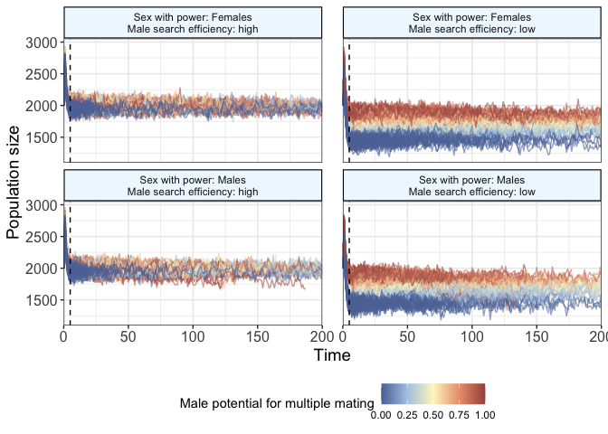

```r
a_pop <-
  autosome_results %>%
  filter(chromosome == "A" & !(time %% 1)) %>%
  mutate(D_prop = D*-1,
         sex_expressed = case_when(sex_expressed == 0 ~ "Males",
                                   .default = "Females"),
         v_cat = case_when(v == 0.008 ~ "low",
                           .default = "high")) %>%
  ggplot(aes(x = time, y = pop_size, colour = refractory_period_prop_cohort_alive)) +
  geom_line(aes(group = parameter_space_ID), alpha = 0.6) +
  geom_vline(xintercept = 5, linetype = 2) +
  #geom_smooth(linewidth = 2) +
  scale_x_continuous(expand = c(0, 0), limits = c(0, 200)) +
  #scale_y_continuous(expand = c(0, 0), limits = c(0, 0.5)) +
  scale_colour_gradientn(colours = temp) +
  labs(x = "Time",
       y = "Population size",
       colour = "Male potential for multiple mating") +
  facet_wrap(sex_expressed~v_cat, nrow = 2,
             labeller =
               label_glue('Sex with power: {`sex_expressed`}\nMale search efficiency: {`v_cat`}')) +
  theme_bw() +
  theme(axis.title = element_text(size = 14),
        axis.title.y = element_markdown(),
        strip.background = element_rect(colour = "black", fill = "aliceblue", linewidth = .8),
        axis.text = element_text(size = 12),
        legend.position = "bottom",
        panel.spacing.x = unit(6, "mm"))


a_pop
```

**X chromosome**

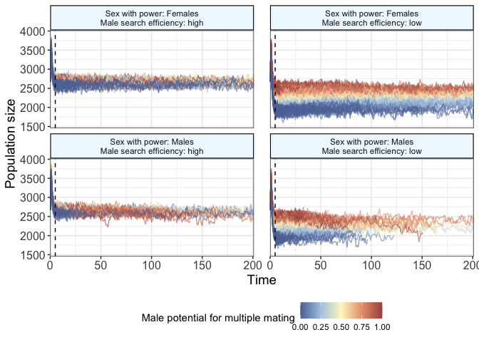

```r
X_pop <-
  X_results %>%
  filter(chromosome == "X" & !(time %% 1)) %>%
  mutate(D_prop = D*-1,
         sex_expressed = case_when(sex_expressed == 0 ~ "Males",
                                   .default = "Females"),
         v_cat = case_when(v == 0.006 ~ "low",
                           .default = "high")) %>%
  ggplot(aes(x = time, y = pop_size, colour = refractory_period_prop_cohort_alive)) +
  geom_line(aes(group = parameter_space_ID), alpha = 0.6) +
  geom_vline(xintercept = 5, linetype = 2) +
  #geom_smooth(linewidth = 2) +
  scale_x_continuous(expand = c(0, 0), limits = c(0, 201)) +
  #scale_y_continuous(expand = c(0, 0), limits = c(0, 0.5)) +
  scale_colour_gradientn(colours = temp) +
  labs(x = "Time",
       y = "Population size",
       colour = "Male potential for multiple mating") +
  facet_wrap(sex_expressed~v_cat, nrow = 2,
             labeller =
               label_glue('Sex with power: {`sex_expressed`}\nMale search efficiency: {`v_cat`}')) +
  theme_bw() +
  theme(axis.title = element_text(size = 14),
        axis.title.y = element_markdown(),
        strip.background = element_rect(colour = "black", fill = "aliceblue", linewidth = .8),
        axis.text = element_text(size = 12),
        legend.position = "bottom",
         panel.spacing.x = unit(6, "mm"))

X_pop
```

**Z chromosome**

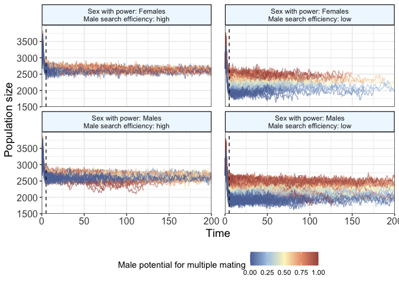

```r
Z_pop <-
  Z_results %>%
  filter(chromosome == "Z" & !(time %% 1)) %>%
  mutate(D_prop = D*-1,
         sex_expressed = case_when(sex_expressed == 0 ~ "Males",
                                   .default = "Females"),
         v_cat = case_when(v == 0.006 ~ "low",
                           .default = "high")) %>%
  ggplot(aes(x = time, y = pop_size, colour = refractory_period_prop_cohort_alive)) +
  geom_line(aes(group = parameter_space_ID), alpha = 0.6) +
  geom_vline(xintercept = 5, linetype = 2) +
  #geom_smooth(linewidth = 2) +
  scale_x_continuous(expand = c(0, 0), limits = c(0, 200)) +
  #scale_y_continuous(expand = c(0, 0), limits = c(0, 0.5)) +
  scale_colour_gradientn(colours = temp) +
  labs(x = "Time",
       y = "Population size",
       colour = "Male potential for multiple mating") +
  facet_wrap(sex_expressed~v_cat, nrow = 2,
             labeller =
               label_glue('Sex with power: {`sex_expressed`}\nMale search efficiency: {`v_cat`}')) +
  theme_bw() +
  theme(axis.title = element_text(size = 14),
        axis.title.y = element_markdown(),
        strip.background = element_rect(colour = "black", fill = "aliceblue", linewidth = .8),
        axis.text = element_text(size = 12),
        legend.position = "bottom",
         panel.spacing.x = unit(6, "mm"))

Z_pop
```

**W chromosome**

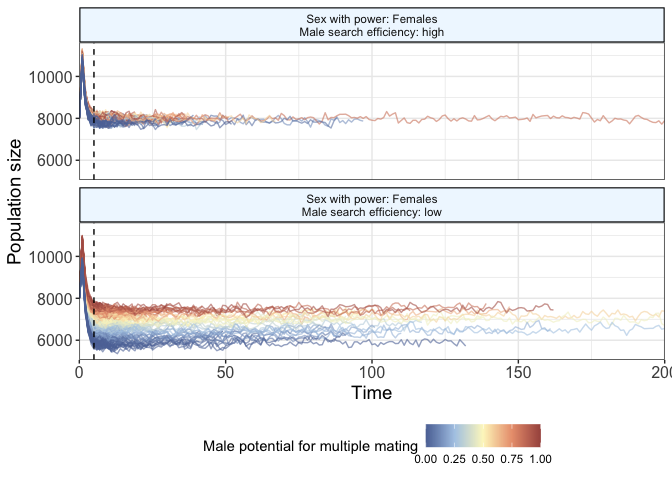

```r
W_pop <-
  W_results %>%
  filter(chromosome == "W" & !(time %% 1)) %>%
  mutate(D_prop = D*-1,
         sex_expressed = case_when(sex_expressed == 0 ~ "Males",
                                   .default = "Females"),
         v_cat = case_when(v == 0.002 ~ "low",
                           .default = "high")) %>%
  ggplot(aes(x = time, y = pop_size, colour = refractory_period_prop_cohort_alive)) +
  geom_line(aes(group = parameter_space_ID), alpha = 0.6) +
  geom_vline(xintercept = 5, linetype = 2) +
  #geom_smooth(linewidth = 2) +
  scale_x_continuous(expand = c(0, 0), limits = c(0, 200)) +
  #scale_y_continuous(expand = c(0, 0), limits = c(0, 0.5)) +
  scale_colour_gradientn(colours = temp) +
  labs(x = "Time",
       y = "Population size",
       colour = "Male potential for multiple mating") +
  facet_wrap(sex_expressed~v_cat, nrow = 2,
             labeller =
               label_glue('Sex with power: {`sex_expressed`}\nMale search efficiency: {`v_cat`}')) +
  theme_bw() +
  theme(axis.title = element_text(size = 14),
        axis.title.y = element_markdown(),
        strip.background = element_rect(colour = "black", fill = "aliceblue", linewidth = .8),
        axis.text = element_text(size = 12),
        legend.position = "bottom",
         panel.spacing.x = unit(6, "mm"))

W_pop
```

**Y chromosome**

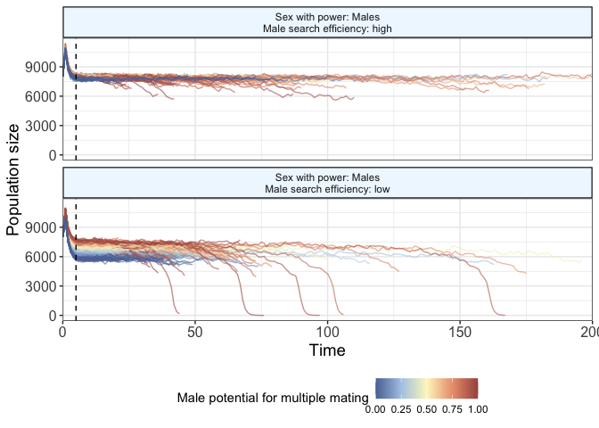

```r
Y_pop <-
  Y_results %>%
  filter(chromosome == "Y" & !(time %% 1)) %>%
  mutate(D_prop = D*-1,
         sex_expressed = case_when(sex_expressed == 0 ~ "Males",
                                   .default = "Females"),
         v_cat = case_when(v == 0.002 ~ "low",
                           .default = "high")) %>%
  ggplot(aes(x = time, y = pop_size, colour = refractory_period_prop_cohort_alive)) +
  geom_line(aes(group = parameter_space_ID), alpha = 0.6) +
  geom_vline(xintercept = 5, linetype = 2) +
  #geom_smooth(linewidth = 2) +
  scale_x_continuous(expand = c(0, 0), limits = c(0, 200)) +
  #scale_y_continuous(expand = c(0, 0), limits = c(0, 0.5)) +
  scale_colour_gradientn(colours = temp) +
  labs(x = "Time",
       y = "Population size",
       colour = "Male potential for multiple mating") +
  facet_wrap(sex_expressed~v_cat, nrow = 2,
             labeller =
               label_glue('Sex with power: {`sex_expressed`}\nMale search efficiency: {`v_cat`}')) +
  theme_bw() +
  theme(axis.title = element_text(size = 14),
        axis.title.y = element_markdown(),
        strip.background = element_rect(colour = "black", fill = "aliceblue", linewidth = .8),
        axis.text = element_text(size = 12),
        legend.position = "bottom",
         panel.spacing.x = unit(6, "mm"))

Y_pop
```

**Maternally inherited cytoplasmic chromosome**

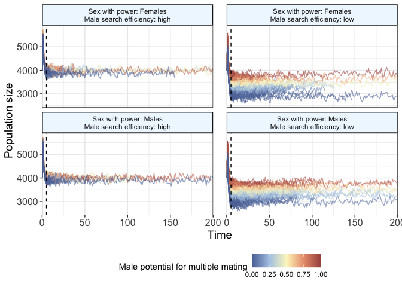

```r
C_m_pop <-
  C_results %>%
  filter(chromosome == "C" & !(time %% 1)) %>%
  mutate(D_prop = D*-1,
         sex_expressed = case_when(sex_expressed == 0 ~ "Males",
                                   .default = "Females"),
         v_cat = case_when(v == 0.004 ~ "low",
                           .default = "high")) %>%
  ggplot(aes(x = time, y = pop_size, colour = refractory_period_prop_cohort_alive)) +
  geom_line(aes(group = parameter_space_ID), alpha = 0.6) +
  geom_vline(xintercept = 5, linetype = 2) +
  #geom_smooth(linewidth = 2) +
  scale_x_continuous(expand = c(0, 0), limits = c(0, 200)) +
  #scale_y_continuous(expand = c(0, 0), limits = c(0, 0.5)) +
  scale_colour_gradientn(colours = temp) +
  labs(x = "Time",
       y = "Population size",
       colour = "Male potential for multiple mating") +
  facet_wrap(sex_expressed~v_cat, nrow = 2,
             labeller =
               label_glue('Sex with power: {`sex_expressed`}\nMale search efficiency: {`v_cat`}')) +
  theme_bw() +
  theme(axis.title = element_text(size = 14),
        axis.title.y = element_markdown(),
        strip.background = element_rect(colour = "black", fill = "aliceblue", linewidth = .8),
        axis.text = element_text(size = 12),
        legend.position = "bottom",
         panel.spacing.x = unit(6, "mm"))

C_m_pop
```

**Paternally inherited cytoplasmic chromosome**

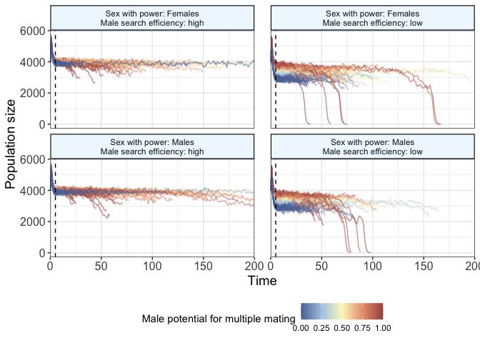

```r
C_P_pop <-
  P_results %>%
  filter(chromosome == "P" & !(time %% 1)) %>%
  mutate(D_prop = D*-1,
         sex_expressed = case_when(sex_expressed == 0 ~ "Males",
                                   .default = "Females"),
         v_cat = case_when(v == 0.004 ~ "low",
                           .default = "high")) %>%
  ggplot(aes(x = time, y = pop_size, colour = refractory_period_prop_cohort_alive)) +
  geom_line(aes(group = parameter_space_ID), alpha = 0.6) +
  geom_vline(xintercept = 5, linetype = 2) +
  #geom_smooth(linewidth = 2) +
  scale_x_continuous(expand = c(0, 0), limits = c(0, 200)) +
  #scale_y_continuous(expand = c(0, 0), limits = c(0, 0.5)) +
  scale_colour_gradientn(colours = temp) +
  labs(x = "Time",
       y = "Population size",
       colour = "Male potential for multiple mating") +
  facet_wrap(sex_expressed~v_cat, nrow = 2,
             labeller =
               label_glue('Sex with power: {`sex_expressed`}\nMale search efficiency: {`v_cat`}')) +
  theme_bw() +
  theme(axis.title = element_text(size = 14),
        axis.title.y = element_markdown(),
        strip.background = element_rect(colour = "black", fill = "aliceblue", linewidth = .8),
        axis.text = element_text(size = 12),
        legend.position = "bottom",
         panel.spacing.x = unit(6, "mm"))

C_P_pop
```

**Building Figure S1**

Wrangle the data for plotting. Basically, bind it all into one dataframe and give everything nice names.

```r
Prop_mated_series <-
  bind_rows(

    autosome_results %>%
      filter(chromosome == "A" & !(time %% 1)) %>%
      mutate(D_prop = D*-1,
             sex_expressed = case_when(sex_expressed == 0 ~ "Males have power",
                                       .default = "Females have power"),
             v_cat = case_when(v == 0.008 ~ "Low",
                               .default = "High"),
             chromosome = "Autosome") %>%
      select(parameter_space_ID, time, prop_mated, chromosome, sex_expressed, mutation_time, v_cat),

    X_results %>%
      filter(chromosome == "X" & !(time %% 1)) %>%
      mutate(D_prop = D*-1,
             sex_expressed = case_when(sex_expressed == 0 ~ "Males have power",
                                       .default = "Females have power"),
             v_cat = case_when(v == 0.006 ~ "Low",
                               .default = "High")) %>%
      select(parameter_space_ID, time, prop_mated, chromosome, sex_expressed, mutation_time, v_cat),

    Z_results %>%
      filter(chromosome == "Z" & !(time %% 1)) %>%
      mutate(D_prop = D*-1,
             sex_expressed = case_when(sex_expressed == 0 ~ "Males have power",
                                       .default = "Females have power"),
             v_cat = case_when(v == 0.006 ~ "Low",
                               .default = "High")) %>%
      select(parameter_space_ID, time, prop_mated, chromosome, sex_expressed, mutation_time, v_cat),

    W_results %>%
      filter(chromosome == "W" & !(time %% 1)) %>%
      mutate(D_prop = D*-1,
             sex_expressed = case_when(sex_expressed == 0 ~ "Males have power",
                                       .default = "Females have power"),
             v_cat = case_when(v == 0.002 ~ "Low",
                               .default = "High")) %>%
      select(parameter_space_ID, time, prop_mated, chromosome, sex_expressed, mutation_time, v_cat),

    Y_results %>%
      filter(chromosome == "Y" & !(time %% 1)) %>%
      mutate(D_prop = D*-1,
             sex_expressed = case_when(sex_expressed == 0 ~ "Males have power",
                                       .default = "Females have power"),
             v_cat = case_when(v == 0.002 ~ "Low",
                               .default = "High")) %>%
      select(parameter_space_ID, time, prop_mated, chromosome, sex_expressed, mutation_time, v_cat),

    C_results %>%
      filter(chromosome == "C" & !(time %% 1)) %>%
      mutate(D_prop = D*-1,
             sex_expressed = case_when(sex_expressed == 0 ~ "Males have power",
                                       .default = "Females have power"),
             v_cat = case_when(v == 0.004 ~ "Low",
                               .default = "High"),
             chromosome = "Cyto. (m)") %>%
      select(parameter_space_ID, time, prop_mated, chromosome, sex_expressed, mutation_time, v_cat),

    P_results %>%
      filter(chromosome == "P" & !(time %% 1)) %>%
      mutate(D_prop = D*-1,
             sex_expressed = case_when(sex_expressed == 0 ~ "Males have power",
                                       .default = "Females have power"),
             v_cat = case_when(v == 0.004 ~ "Low",
                               .default = "High"),
             chromosome = "Cyto. (p)") %>%
      select(parameter_space_ID, time, prop_mated, chromosome, sex_expressed, mutation_time, v_cat)
  )
```

Plot the proportion of females that find mates in their lifetime. The purpose of this plot is to show the difference between the rapid mate searching scenario and the inefficient searching scenario, the latter of which should accentuate the importance of inbreeding for reproductive assurance.

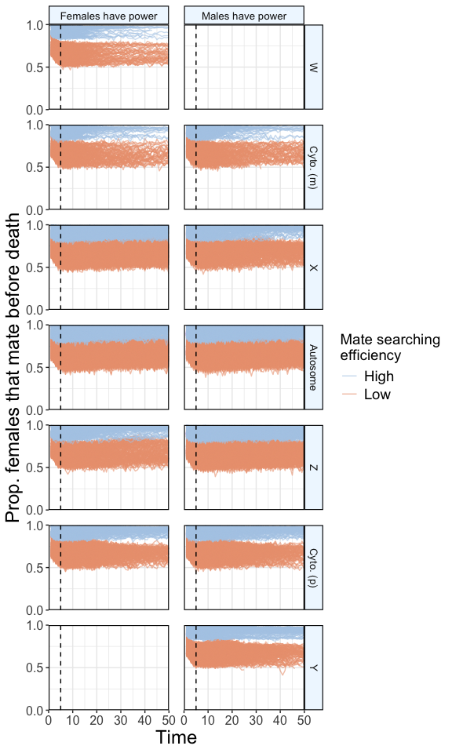

```r
Prop_mated_series %>%
  ggplot(aes(x = time, y = prop_mated, colour = v_cat)) +
  geom_line(aes(group = parameter_space_ID), alpha = 0.6) +
  geom_vline(xintercept = 5, linetype = 2) +
  scale_x_continuous(expand = c(0, 0), limits = c(0, 50)) +
  scale_y_continuous(expand = c(0, 0), breaks = c(0, 0.5,1)) +
  scale_colour_manual(values = c(pnw_palette("Shuksan2")[2],
                                 pnw_palette("Shuksan2")[4])) +
  labs(x = "Time",
       y = "Prop. females that mate before death",
       colour = "Mate searching\nefficiency") +
  facet_grid(factor(chromosome, levels = c("W", "Cyto. (m)", "X", "Autosome",
                                           "Z", "Cyto. (p)", "Y"))~sex_expressed) +
  theme_bw() +
  theme(panel.border = element_rect(fill = NA, colour = "black", size = .8),
        strip.background = element_rect(colour = "black", fill = "Aliceblue", linewidth = .8),
        strip.text = element_text(size = 10),
        axis.title.x = element_text(size = 18),
        axis.title.y = element_text(size = 18),
        axis.text = element_text(size =12),
        legend.title = element_text(size = 14),
        legend.text = element_text(size = 14),
        #legend.position = "bottom",
        panel.spacing = unit(1, "lines"))
```

**Figure S1**. The effect of mate searching efficiency on female matelessness. Each line shows the outcome of a single simulation run at the end of the first 50 time units for parameter values indicated on the axes. Orange and blue trajectories indicate simulation runs where males have low ($v=8$) and high ($v=80$) mate searching capabilities, respectively. The dotted line indicates the appearance of the inbreeding acceptance alleles in the population.

### Building Figure 2

Prep data for plotting. We first extract the final $I$ allele frequencies from each simulation run and categorise the outcome as either i) Population crash (<100 individuals), ii) purging of the $I$ allele or iii) $I$ approaches fixation.

```r
A_data <-
  autosome_results %>%
  group_by(parameter_space_ID) %>%
  slice_tail() %>%
  ungroup() %>%
  mutate(D_prop = D*-1,
         Fate = case_when(pop_size < 100 ~ "Extinction",
                          I_prop  >= 0.9 ~ "Invades",
                          I_prop  < 0.001 ~ "Purged"),
         sex_expressed = case_when(sex_expressed == 0 ~ "Males have power",
                                   .default = "Females have power"),
         v_cat = case_when(v == 0.008 ~ "Low",
                           .default = "High"))

X_data <-
  X_results %>%
  group_by(parameter_space_ID) %>%
  slice_tail() %>%
  ungroup() %>%
  mutate(D_prop = D*-1,
         Fate = case_when(pop_size < 100 ~ "Extinction",
                          I_prop  >= 0.9 ~ "Invades",
                          I_prop  < 0.001 ~ "Purged"),
         sex_expressed = case_when(sex_expressed == 0 ~ "Males have power",
                                   .default = "Females have power"),
         v_cat = case_when(v == 0.006 ~ "Low",
                           .default = "High"))

Z_data <-
  Z_results %>%
  group_by(parameter_space_ID) %>%
  slice_tail() %>%
  ungroup() %>%
  mutate(D_prop = D*-1,
         Fate = case_when(pop_size < 100 ~ "Extinction",
                          I_prop  >= 0.9 ~ "Invades",
                          I_prop  < 0.001 ~ "Purged"),
         sex_expressed = case_when(sex_expressed == 0 ~ "Males have power",
                                   .default = "Females have power"),
         v_cat = case_when(v == 0.006 ~ "Low",
                           .default = "High"))

W_data <-
  W_results %>%
  group_by(parameter_space_ID) %>%
  slice_tail() %>%
  ungroup() %>%
  mutate(D_prop = D*-1,
         Fate = case_when(pop_size < 100 ~ "Extinction",
                          I_prop  >= 0.9 ~ "Invades",
                          I_prop  < 0.001 ~ "Purged"),
         sex_expressed = case_when(sex_expressed == 0 ~ "Males have power",
                                   .default = "Females have power"),
         v_cat = case_when(v == 0.002 ~ "Low",
                           .default = "High"))

Y_data <-
  Y_results %>%
  group_by(parameter_space_ID) %>%
  slice_tail() %>%
  ungroup() %>%
  mutate(D_prop = D*-1,
         Fate = case_when(pop_size < 100 ~ "Extinction",
                          I_prop  >= 0.9 ~ "Invades",
                          I_prop  < 0.001 ~ "Purged"),
         sex_expressed = case_when(sex_expressed == 0 ~ "Males have power",
                                   .default = "Females have power"),
         v_cat = case_when(v == 0.002 ~ "Low",
                           .default = "High"))

C_data <-
  C_results %>%
  group_by(parameter_space_ID) %>%
  slice_tail() %>%
  ungroup() %>%
  mutate(D_prop = D*-1,
         Fate = case_when(pop_size < 100 ~ "Extinction",
                          I_prop  >= 0.9 ~ "Invades",
                          I_prop  < 0.001 ~ "Purged"),
         sex_expressed = case_when(sex_expressed == 0 ~ "Males have power",
                                   .default = "Females have power"),
         v_cat = case_when(v == 0.004 ~ "Low",
                           .default = "High"))

P_data <-
  P_results %>%
  group_by(parameter_space_ID) %>%
  slice_tail() %>%
  ungroup() %>%
  mutate(D_prop = D*-1,
         Fate = case_when(pop_size < 100 ~ "Extinction",
                          I_prop  >= 0.9 ~ "Invades",
                          I_prop  < 0.001 ~ "Purged"),
         sex_expressed = case_when(sex_expressed == 0 ~ "Males have power",
                                   .default = "Females have power"),
         v_cat = case_when(v == 0.004 ~ "Low",
                           .default = "High"))
```

Stitch data together into one dataframe for plotting

```r
# check for pop crashes

#A_data |> filter(pop_size < 100)
#X_data |> filter(pop_size < 100)
#Z_data |> filter(pop_size < 100)
#W_data |> filter(pop_size < 100)
# no crashes above, but some crashes for the below
Extinctions <-
  bind_rows(
    Y_data |>
      filter(pop_size < 100) |>
      select(D_prop, refractory_period_prop_cohort_alive, sex_expressed) |>
      mutate(Extinction = 1,
             chromosome = "Y"),

    P_data |>
      filter(pop_size < 100) |>
      select(D_prop, refractory_period_prop_cohort_alive, sex_expressed) |>
      mutate(Extinction = 1,
             chromosome = "Cyto. (p)")
  )



Fig2_data <-
  bind_rows(

    A_data %>%
      filter(dominance == 1) %>%
      select(I_prop,
             sex_expressed,
             v_cat,
             D_prop,
             refractory_period_prop_cohort_alive) %>%
      pivot_wider(id_cols = c(D_prop, refractory_period_prop_cohort_alive, sex_expressed),
                  names_from = v_cat, values_from = I_prop) %>%
      mutate(Result = case_when(High >= 0.9 ~ "Fixes with high\nencounter rate",
                                Low >= 0.9 & High < 0.9 ~ "Extra fixation with\nlow encounter rate",
                                Low < 0.9 & High < 0.9 ~ "Does not fix"),
             chromosome = "Autosome"),


    X_data %>%
      filter(dominance == 1) %>%
      select(I_prop,
             sex_expressed,
             v_cat,
             D_prop,
             refractory_period_prop_cohort_alive) %>%
      pivot_wider(id_cols = c(D_prop, refractory_period_prop_cohort_alive, sex_expressed),
                  names_from = v_cat, values_from = I_prop) %>%
      mutate(Result = case_when(High >= 0.9 ~ "Fixes with high\nencounter rate",
                                Low >= 0.9 & High < 0.9 ~ "Extra fixation with\nlow encounter rate",
                                Low < 0.9 & High < 0.9 ~ "Does not fix"),
             chromosome = "X"),

    Z_data %>%
      filter(dominance == 1) %>%
      select(I_prop,
             sex_expressed,
             v_cat,
             D_prop,
             refractory_period_prop_cohort_alive) %>%
      pivot_wider(id_cols = c(D_prop, refractory_period_prop_cohort_alive, sex_expressed),
                  names_from = v_cat, values_from = I_prop) %>%
      mutate(Result = case_when(High >= 0.9 ~ "Fixes with high\nencounter rate",
                                Low >= 0.9 & High < 0.9 ~ "Extra fixation with\nlow encounter rate",
                                Low < 0.9 & High < 0.9 ~ "Does not fix"),
             chromosome = "Z"),

    W_data %>%
      filter(dominance == 1) %>%
      select(I_prop,
             sex_expressed,
             v_cat,
             D_prop,
             refractory_period_prop_cohort_alive) %>%
      pivot_wider(id_cols = c(D_prop, refractory_period_prop_cohort_alive, sex_expressed),
                  names_from = v_cat, values_from = I_prop) %>%
      mutate(Result = case_when(High >= 0.9 ~ "Fixes with high\nencounter rate",
                                Low >= 0.9 & High < 0.9 ~ "Extra fixation with\nlow encounter rate",
                                Low < 0.9 & High < 0.9 ~ "Does not fix"),
             chromosome = "W"),
    # this is dummy code to produce an all white panel when ggplot expects a W in males
    W_data %>%
      filter(dominance == 1) %>%
      select(I_prop,
             sex_expressed,
             v_cat,
             D_prop,
             refractory_period_prop_cohort_alive) %>%
      pivot_wider(id_cols = c(D_prop, refractory_period_prop_cohort_alive, sex_expressed),
                  names_from = v_cat, values_from = I_prop) %>%
      mutate(Result = "Not present",
             sex_expressed = "Males have power",
             chromosome = "W"),

    Y_data %>%
      filter(dominance == 1) %>%
      select(I_prop,
             sex_expressed,
             v_cat,
             D_prop,
             refractory_period_prop_cohort_alive) %>%
      pivot_wider(id_cols = c(D_prop, refractory_period_prop_cohort_alive, sex_expressed),
                  names_from = v_cat, values_from = I_prop) %>%
      mutate(Result = case_when(High >= 0.9 ~ "Fixes with high\nencounter rate",
                                Low >= 0.9 & High < 0.9 ~ "Extra fixation with\nlow encounter rate",
                                Low < 0.9 & High < 0.9 ~ "Does not fix"),
             chromosome = "Y"),
    # this is dummy code to produce an all white panel when ggplot expects a W in males
    Y_data %>%
      filter(dominance == 1) %>%
      select(I_prop,
             sex_expressed,
             v_cat,
             D_prop,
             refractory_period_prop_cohort_alive) %>%
      pivot_wider(id_cols = c(D_prop, refractory_period_prop_cohort_alive, sex_expressed),
                  names_from = v_cat, values_from = I_prop) %>%
      mutate(Result = "Not present",
             sex_expressed = "Females have power",
             chromosome = "Y"),

    C_data %>%
      filter(dominance == 1) %>%
      select(I_prop,
             sex_expressed,
             v_cat,
             D_prop,
             refractory_period_prop_cohort_alive) %>%
      pivot_wider(id_cols = c(D_prop, refractory_period_prop_cohort_alive, sex_expressed),
                  names_from = v_cat, values_from = I_prop) %>%
      mutate(Result = case_when(High >= 0.9 ~ "Fixes with high\nencounter rate",
                                Low >= 0.9 & High < 0.9 ~ "Extra fixation with\nlow encounter rate",
                                Low < 0.9 & High < 0.9 ~ "Does not fix"),
             chromosome = "Cyto. (m)"),

    P_data %>%
      filter(dominance == 1) %>%
      select(I_prop,
             sex_expressed,
             v_cat,
             D_prop,
             refractory_period_prop_cohort_alive) %>%
      pivot_wider(id_cols = c(D_prop, refractory_period_prop_cohort_alive, sex_expressed),
                  names_from = v_cat, values_from = I_prop) %>%
      mutate(Result = case_when(High >= 0.9 ~ "Fixes with high\nencounter rate",
                                Low >= 0.9 & High < 0.9 ~ "Extra fixation with\nlow encounter rate",
                                Low < 0.9 & High < 0.9 ~ "Does not fix"),
             chromosome = "Cyto. (p)"),

  ) |>
  left_join(Extinctions) |>
  mutate(Result = case_when(Extinction == 1 ~ "Pop crash with\nlow encounter rate",
                            .default = Result))
```

plot

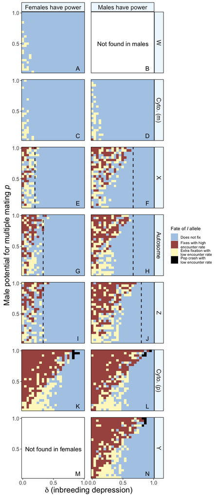

```r
# Annotation layer data
letter_labels <-
  expand_grid(chromosome = c("W", "Cyto. (m)", "X", "Autosome",
                             "Z", "Cyto. (p)", "Y"),
              sex_expressed = c("Females have power", "Males have power")) %>%
  mutate(D_prop = 0.9,
         y = 0.1,
         label = c("A", "B", "C", "D", "E", "F", "G", "H", "I",
                   "J", "K", "L", "M", "N"))

# getting the colours and legend to work

legend_list <-
  c("Does not fix",
    "Fixes with high\nencounter rate",
    "Extra fixation with\nlow encounter rate",
    "Pop crash with\nlow encounter rate",
    "Not present")

legend_breaks <-
  c("Does not fix",
    "Fixes with high\nencounter rate",
    "Extra fixation with\nlow encounter rate",
    "Pop crash with\nlow encounter rate")

col_vector <-
  c("#b0cbe7",
    #"#eba07e",
    "#a8554e",
    "#fef7c7",
    "black",
    "white")

# need this trick to get all colours on figure but only a subset reported in legend

names(col_vector) <-
  legend_list

# W and Y annotation layer

W_Y_annotation <-
  tibble(chromosome = c("W", "Y"),
              sex_expressed = c("Males have power", "Females have power")) %>%
  mutate(D_prop = 0.5,
         y = 0.5,
         label = c("Not found in males", "Not found in females"))


Fig2_data %>%
  # hacky solution to ploty axis properly
  group_by(refractory_period_prop_cohort_alive) |>
  mutate(hacky_solution_y = cur_group_id()/26) |>
  ungroup() |>
  ggplot(aes(x = D_prop, y = hacky_solution_y)) +
  geom_blank() +
  geom_tile(aes(fill = Result), alpha = 1) +
  scale_fill_manual(values = col_vector, breaks = legend_breaks) +
  labs(x = ~delta~'(inbreeding depression)',
       y = "Male potential for multiple mating _p_",
       fill = "Fate of _I_ allele") +
  facet_grid(factor(chromosome, levels = c("W", "Cyto. (m)", "X", "Autosome",
                                           "Z", "Cyto. (p)", "Y")) ~ sex_expressed) +

  geom_vline(data = Fig2_data %>%
               filter(sex_expressed == "Males have power", chromosome == "Autosome"),
             aes(xintercept = 1/(1 + 0.5*1)), linetype = 2, colour = "black", linewidth = .8) +
  geom_vline(data = Fig2_data %>%
               filter(sex_expressed == "Females have power", chromosome == "Autosome"),
             aes(xintercept = (0.5*1)/(1 + 0.5*1)), linetype = 2, colour = "black", linewidth = .8) +

  geom_vline(data = Fig2_data %>% filter(sex_expressed == "Males have power" , chromosome == "X"),
             aes(xintercept = 1/(1 + 0.5)), linetype = 2, colour = "black", linewidth = .8) +

  geom_vline(data = Fig2_data %>% filter(sex_expressed == "Females have power" , chromosome == "X"),
             aes(xintercept = 1/5), linetype = 2, colour = "black", linewidth = .8) +

  geom_vline(data = Fig2_data %>% filter(sex_expressed == "Males have power", chromosome == "Z"),
             aes(xintercept = 4/5), linetype = 2, colour = "black", linewidth = .8) +

  geom_vline(data = Fig2_data %>% filter(sex_expressed == "Females have power", chromosome == "Z"),
             aes(xintercept = 1/3), linetype = 2, colour = "black", linewidth = .8) +

  # add panel identifiers
  geom_text(data = letter_labels, aes(label = label, x = D_prop, y), size = 5) +
  geom_text(data = W_Y_annotation, aes(label = label, x = D_prop, y), size = 5) +
  coord_fixed() +
  scale_x_continuous(expand = c(0, 0), breaks = c(0, 0.5, 1)) +
  scale_y_continuous(expand = c(0, 0), breaks = c(0, 0.5, 1)) +
  theme(panel.border = element_rect(fill = NA, colour = "black", size = .8),
        strip.background = element_rect(colour = "black", fill = "aliceblue", linewidth = .8),
        strip.text = element_text(size = 14),
        axis.title.x = element_text(size = 18),
        axis.title.y = element_markdown(size = 18),
        axis.text = element_text(size =12),
        legend.title = element_markdown(),
        panel.spacing = unit(1, "lines"))
```

**Figure 2**. Results generated by stochastic population genetic simulations. Panels show the conditions where dominant inbreeding alleles invade to a high frequency (0.9) when females (left column) or males (right column) have power over the outcome of mating interactions, for genes found on W, maternally inherited cytoplasmic, X, Autosomal, Z, paternally inherited cytoplasmic and Y chromosomes. Inbreeding depression $\delta$ is quantified as the mean proportion of lifespan lost relative to an outbred individual, while the potential for multiple mating is operationally defined as the probability $p$ that an outbred male (with expected lifespan 1) can return to the mating pool alive upon completing the refractory period (see Supplementary section S2 for derivations of $\delta$ and $p$). The dashed lines show $\delta_{i, \mathrm{f}}^*$ and $\delta_{i, \mathrm{m}}^*$. Note that each pixel reports the outcome of precisely two simulation runs, one where male-female encounters are common ($v = 80$) and another where they are rare ($v = 8$). The mosaic nature of the plot therefore reveals the stochasticity of outcomes when invasion begins with a small number of mutants per run. While inbreeding is therefore never guaranteed to invade, the plot allows identifying parameter regions where it never spreads, as opposed to often doing so. Results are for initial individual population sizes that collectively harbour 4000 gene copies at the relevant locus. Other parameters used in all panels: $C=5$ and $n=5$.

### Building Figure S2

Plotting results over the fine-scale parameter space, for autosomal, X- and Z-linked regions.

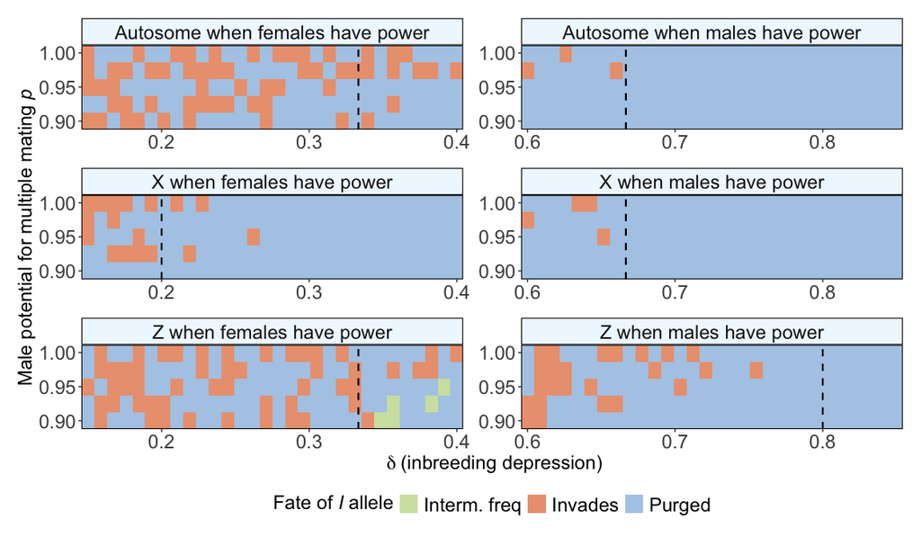

```r
data_fine <-
  bind_rows(
    autosome_results_fine %>%
      group_by(parameter_space_ID) %>%
      slice_tail() %>%
      ungroup() %>%
      mutate(D_prop = D*-1,
             Fate = case_when(pop_size < 10 ~ "Extinction",
                              I_prop  >= 0.9 ~ "Invades",
                              I_prop  < 0.001 ~ "Purged",
                              .default = "Interm. freq"),
             sex_expressed = case_when(sex_expressed == 0 ~ "males",
                                       .default = "females"),
            # v_cat = case_when(v == 0.008 ~ "Low",
             #                  .default = "High"),
             chromosome = "Autosome") %>%
      select(I_prop,
             chromosome,
             D_prop,
             refractory_period_prop_cohort_alive,
             sex_expressed,
             Fate,
             parameter_space_ID),

    X_results_fine %>%
      group_by(parameter_space_ID) %>%
      slice_tail() %>%
      ungroup() %>%
      mutate(D_prop = D*-1,
             Fate = case_when(pop_size < 10 ~ "Extinction",
                              I_prop  >= 0.9 ~ "Invades",
                              I_prop  < 0.001 ~ "Purged",
                              .default = "Interm. freq"),
             sex_expressed = case_when(sex_expressed == 0 ~ "males",
                                       .default = "females")) %>%
      select(I_prop,
             chromosome,
             D_prop,
             refractory_period_prop_cohort_alive,
             sex_expressed,
             Fate,
             parameter_space_ID),

    Z_results_fine %>%
      group_by(parameter_space_ID) %>%
      slice_tail() %>%
      ungroup() %>%
      mutate(D_prop = D*-1,
             Fate = case_when(pop_size < 10 ~ "Extinction",
                              I_prop  >= 0.9 ~ "Invades",
                              I_prop  < 0.001 ~ "Purged",
                              .default = "Interm. freq"),
             sex_expressed = case_when(sex_expressed == 0 ~ "males",
                                       .default = "females")) %>%
      select(I_prop,
             chromosome,
             D_prop,
             refractory_period_prop_cohort_alive,
             sex_expressed,
             Fate,
             parameter_space_ID)
  )

heatmap_fine <-
  data_fine %>%
  ggplot(aes(x = D_prop, y = refractory_period_prop_cohort_alive)) +
  geom_blank() +
  geom_tile(aes(fill = Fate), alpha = 1) +
  scale_fill_manual(values = c("#d0e2af",
                               pnw_palette("Shuksan2", n = 5)[4],
                               pnw_palette("Shuksan2", n = 5)[2])) +
  labs(x = ~delta~'(inbreeding depression)',
       y = "Male potential for multiple mating _p_",
       fill = "Fate of _I_ allele") +
  facet_wrap(chromosome ~ sex_expressed,
             labeller = label_glue('{`chromosome`} when {`sex_expressed`} have power'),
             scales = "free", nrow = 3) +

  geom_vline(data = data_fine %>%
               filter(sex_expressed == "females", chromosome == "Autosome"),
             aes(xintercept = 0.5/(1 + 0.5*1)), linetype = 2, colour = "black", linewidth = .8) +

  geom_vline(data = data_fine %>%
               filter(sex_expressed == "males", chromosome == "Autosome"),
             aes(xintercept = 1/(1 + 0.5*1)), linetype = 2, colour = "black", linewidth = .8) +

  geom_vline(data = data_fine %>%
               filter(sex_expressed == "females", chromosome == "X"),
             aes(xintercept = 1/5), linetype = 2, colour = "black", linewidth = .8) +

  geom_vline(data = data_fine %>%
               filter(sex_expressed == "males", chromosome == "X"),
             aes(xintercept = 1/(1 + 0.5*1)), linetype = 2, colour = "black", linewidth = .8) +

  geom_vline(data = data_fine %>%
               filter(sex_expressed == "females", chromosome == "Z"),
             aes(xintercept = 1/3), linetype = 2, colour = "black", linewidth = .8) +

  geom_vline(data = data_fine %>%
               filter(sex_expressed == "males", chromosome == "Z"),
             aes(xintercept = 4/5), linetype = 2, colour = "black", linewidth = .8) +

  scale_x_continuous(expand = c(0, 0),
                     breaks = c(0.2, 0.3, 0.4, 0.5, 0.6, 0.7, 0.8)) +
  scale_y_continuous(expand = c(0, 0),
                     breaks = c(0.9, 0.95, 1)) +
  theme(panel.border = element_rect(fill = NA, colour = "black", size = .8),
        strip.background = element_rect(colour = "black", fill = "aliceblue", linewidth = .8),
        strip.text = element_text(size = 18),
        axis.title.x = element_text(size = 18),
        axis.title.y = element_markdown(size = 18),
        axis.text = element_text(size =18),
        legend.position = "bottom",
        legend.title = element_markdown(size = 18),
        legend.text = element_text(size = 18),
        panel.spacing = unit(1, "lines"),
        plot.margin = margin(0.6,0.6,0.6,0.6, "cm"))

heatmap_fine
```

**Figure S2**. Simulation results, for levels of inbreeding depression where the inclusive fitness model predicts i) $\delta_{\mathrm{X, f}}^* < (\delta_{\mathrm{A, f}}^*, \delta_{\mathrm{Z, f}}^*)$, shown in the left column, and ii) $\delta_{\mathrm{Z, m}}^* > (\delta_{\mathrm{A, m}}^*, \delta_{\mathrm{X, m}}^*)$, shown in the right. Panels show the conditions where inbreeding invades to a high frequency (0.9) – or in very rare cases where it is tending towards this cut-off, but had not after 1000 time units – when females (left column) or males (right column) control the outcome of mating interactions. Note that these panels are zoomed in versions of the relevant panels shown in Figure 2, simulated with a finer resolution.

### Building supplementary dominance figures

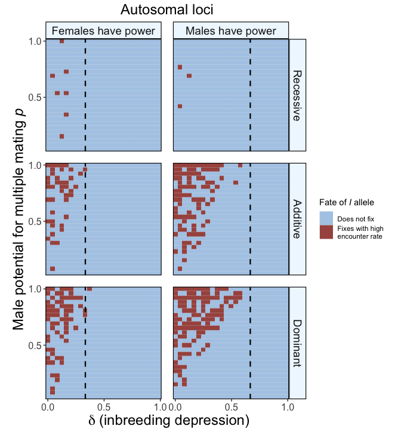

```r
Sunset_1 <- c("#b0cbe7",
              "#a8554e",
            #"#eba07e",
            #"#fef7c7",
            #"#a8554e",
            "white")

A_data_dominance <-
  A_data %>%
  select(I_prop,
         sex_expressed,
         v_cat,
         D_prop,
         refractory_period_prop_cohort_alive,
         pop_size,
         dominance) %>%
  mutate(Result = case_when(v_cat == "Low" & pop_size < 100 ~ "Pop extinction",
                                v_cat == "Low" & I_prop >= 0.9 ~
                                  "Fixes with low\nencounter rate",
                                v_cat == "Low" & I_prop < 0.9 ~ "Does not fix",
                                v_cat == "High" & pop_size < 100 ~ "Pop extinction",
                                v_cat == "High" & I_prop >= 0.9 ~
                                  "Fixes with high\nencounter rate",
                                v_cat == "High" & I_prop < 0.9 ~ "Does not fix"),
         dominance = case_when(dominance == 0 ~ "Recessive",
                               dominance == 0.5 ~ "Additive",
                               .default = "Dominant"))

A_data_dominance %>%
  filter(v_cat == "High") |>
  # hacky solution to ploty axis properly
  group_by(refractory_period_prop_cohort_alive) |>
  mutate(hacky_solution_y = cur_group_id()/26) |>
  ungroup() |>
  ggplot(aes(x = D_prop, y = hacky_solution_y)) +
  geom_blank() +
  geom_tile(aes(fill = Result), alpha = 1) +
  scale_fill_manual(values = Sunset_1) +
  labs(x = ~delta~'(inbreeding depression)',
       y = "Male potential for multiple mating _p_",
       fill = "Fate of _I_ allele",
       title = "Autosomal loci") +
  facet_grid(factor(dominance, levels = c("Recessive", "Additive", "Dominant")) ~ sex_expressed) +

  geom_vline(data = A_data_dominance %>%
               filter(sex_expressed == "Males have power"),
             aes(xintercept = 1/(1 + 0.5*1)), linetype = 2, colour = "black", linewidth = .8) +
  geom_vline(data = A_data_dominance %>%
               filter(sex_expressed == "Females have power"),
             aes(xintercept = (0.5*1)/(1 + 0.5*1)), linetype = 2, colour = "black", linewidth = .8) +
  coord_fixed() +
  scale_x_continuous(expand = c(0, 0), breaks = c(0, 0.5, 1)) +
  scale_y_continuous(expand = c(0, 0), breaks = c(0, 0.5, 1)) +
  theme(panel.border = element_rect(fill = NA, colour = "black", size = .8),
        strip.background = element_rect(colour = "black", fill = "aliceblue", linewidth = .8),
        strip.text = element_text(size = 14),
        axis.title.x = element_text(size = 18),
        axis.title.y = element_markdown(size = 18),
        plot.title = element_text(hjust = 0.5, size = 18),
        axis.text = element_text(size =12),
        legend.title = element_markdown(),
        panel.spacing = unit(1, "lines"))
```

**Figure S3**. Results generated by stochastic population genetic simulations with different dominance coefficients for an autosomal allele. Panels show the conditions where inbreeding invades to a high frequency (0.9), when females (left column) or males (right column) control the outcome of mating interactions and inbreeding acceptance alleles are either completely recessive, additive or dominant. All other details are as in Figure 2. As alleles become more recessive, they are less likely to be expressed while rare, making it more difficult to overcome the drift barrier.

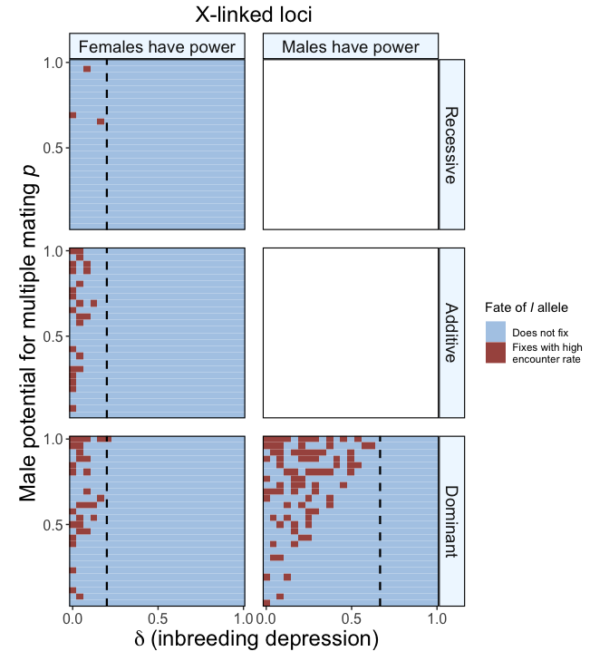

```r
X_data_dominance <-
  X_data %>%
  select(I_prop,
         sex_expressed,
         v_cat,
         D_prop,
         refractory_period_prop_cohort_alive,
         dominance,
         pop_size) %>%
      mutate(Result = case_when(v_cat == "Low" & pop_size < 100 ~ "Pop extinction",
                                v_cat == "Low" & I_prop >= 0.9 ~
                                  "Fixes with low\nencounter rate",
                                v_cat == "Low" & I_prop < 0.9 ~ "Does not fix",
                                v_cat == "High" & pop_size < 100 ~ "Pop extinction",
                                v_cat == "High" & I_prop >= 0.9 ~
                                  "Fixes with high\nencounter rate",
                                v_cat == "High" & I_prop < 0.9 ~ "Does not fix"),
         dominance = case_when(dominance == 0 ~ "Recessive",
                               dominance == 0.5 ~ "Additive",
                               .default = "Dominant"))

X_data_dominance %>%
  filter(v_cat == "High") |>
  # hacky solution to ploty axis properly
  group_by(refractory_period_prop_cohort_alive) |>
  mutate(hacky_solution_y = cur_group_id()/26) |>
  ungroup() |>
  ggplot(aes(x = D_prop, y = hacky_solution_y)) +
  geom_blank() +
  geom_tile(aes(fill = Result), alpha = 1) +
  scale_fill_manual(values = Sunset_1) +
  labs(x = ~delta~'(inbreeding depression)',
       y = "Male potential for multiple mating _p_",
       fill = "Fate of _I_ allele",
       title = "X-linked loci") +
  facet_grid(factor(dominance, levels = c("Recessive", "Additive", "Dominant")) ~ sex_expressed) +

  geom_vline(data = X_data_dominance %>% filter(sex_expressed == "Males have power"),
             aes(xintercept = 2/3), linetype = 2, colour = "black", linewidth = .8) +
  geom_vline(data = X_data_dominance %>% filter(sex_expressed == "Females have power"),
             aes(xintercept = 1/5), linetype = 2, colour = "black", linewidth = .8) +
  coord_fixed() +
  scale_x_continuous(expand = c(0, 0), breaks = c(0, 0.5, 1)) +
  scale_y_continuous(expand = c(0, 0), breaks = c(0, 0.5, 1)) +
  theme(panel.border = element_rect(fill = NA, colour = "black", size = .8),
        strip.background = element_rect(colour = "black", fill = "aliceblue", linewidth = .8),
        panel.background = element_rect(fill = "white"),
        strip.text = element_text(size = 14),
        axis.title.x = element_text(size = 18),
        axis.title.y = element_markdown(size = 18),
        plot.title = element_text(hjust = 0.5, size = 18),
        axis.text = element_text(size =12),
        legend.title = element_markdown(),
        panel.spacing = unit(1, "lines"))
```

**Figure S4**. Results generated by stochastic population genetic simulations with different dominance coefficients for a X-linked allele. All other details are as in Figure 2. White fill indicates dominance scenarios we do not explore, due to hemizygosity.

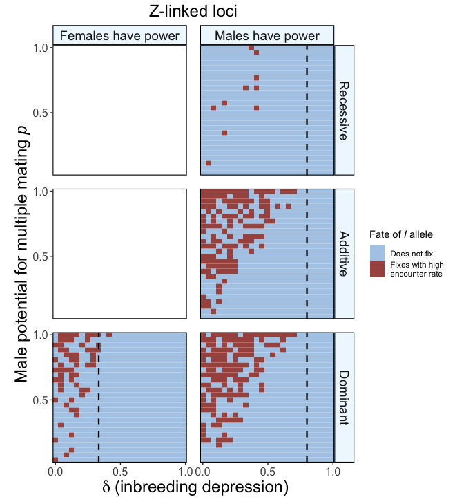

```r
Z_data_dominance <-
  Z_data %>%
  select(I_prop,
         sex_expressed,
         v_cat,
         D_prop,
         refractory_period_prop_cohort_alive,
         dominance,
         pop_size) %>%
  mutate(Result = case_when(v_cat == "Low" & pop_size < 100 ~ "Pop extinction",
                                v_cat == "Low" & I_prop >= 0.9 ~
                                  "Fixes with low\nencounter rate",
                                v_cat == "Low" & I_prop < 0.9 ~ "Does not fix",
                                v_cat == "High" & pop_size < 100 ~ "Pop extinction",
                                v_cat == "High" & I_prop >= 0.9 ~
                                  "Fixes with high\nencounter rate",
                                v_cat == "High" & I_prop < 0.9 ~ "Does not fix"),
         dominance = case_when(dominance == 0 ~ "Recessive",
                               dominance == 0.5 ~ "Additive",
                               .default = "Dominant"))

Z_data_dominance %>%
  filter(v_cat == "High") |>
  # hacky solution to ploty axis properly
  group_by(refractory_period_prop_cohort_alive) |>
  mutate(hacky_solution_y = cur_group_id()/26) |>
  ungroup() |>
  ggplot(aes(x = D_prop, y = hacky_solution_y)) +
  geom_blank() +
  geom_tile(aes(fill = Result), alpha = 1) +
  scale_fill_manual(values = Sunset_1) +
  labs(x = ~delta~'(inbreeding depression)',
       y = "Male potential for multiple mating _p_",
       fill = "Fate of _I_ allele",
       title = "Z-linked loci") +
  facet_grid(factor(dominance, levels = c("Recessive", "Additive", "Dominant")) ~ sex_expressed) +

  geom_vline(data = Z_data_dominance %>% filter(sex_expressed == "Males have power"),
             aes(xintercept = 4/5), linetype = 2, colour = "black", linewidth = .8) +
  geom_vline(data = Z_data_dominance %>% filter(sex_expressed == "Females have power"),
             aes(xintercept = 1/3), linetype = 2, colour = "black", linewidth = .8) +
  coord_fixed() +
  scale_x_continuous(expand = c(0, 0), breaks = c(0, 0.5, 1)) +
  scale_y_continuous(expand = c(0, 0), breaks = c(0, 0.5, 1)) +
  theme(panel.border = element_rect(fill = NA, colour = "black", size = .8),
        strip.background = element_rect(colour = "black", fill = "aliceblue", linewidth = .8),
        panel.background = element_rect(fill = "white"),
        strip.text = element_text(size = 14),
        axis.title.x = element_text(size = 18),
        axis.title.y = element_markdown(size = 18),
        plot.title = element_text(hjust = 0.5, size = 18),
        axis.text = element_text(size =12),
        legend.title = element_markdown(),
        panel.spacing = unit(1, "lines"))
```

**Figure S5**. Results generated by stochastic population genetic simulations with different dominance coefficients for a Z-linked allele. All other details are as in Figure 2. White fill indicates dominance scenarios we do not explore, due to hemizygosity.

```
Analyses were conducted using the R Statistical language (version 4.6.1; R Core
Team, 2026) on macOS Golden Gate 27.0.1, using the packages geomtextpath
(version 0.2.0; Cameron A, van den Brand T, 2025), ggnewscale (version 0.5.2;
Campitelli E, 2025), stickylabeller (version 1.0.0; Goldie J, 2025), lubridate
(version 1.9.5; Grolemund G, Wickham H, 2011), bench (version 1.1.4; Hester J,
Vaughan D, 2025), vroom (version 1.7.1; Hester J et al., 2026), PNWColors
(version 0.1.0; Lawlor J, 2020), report (version 0.6.4; Makowski D et al.,
2023), MetBrewer (version 0.2.0; Mills BR, 2022), MoMAColors (version
0.0.0.9000; Mills BR, 2026), tibble (version 3.3.1; Müller K, Wickham H, 2026),
patchwork (version 1.3.2; Pedersen T, 2025), ggplot2 (version 4.0.3; Wickham H,
2016), forcats (version 1.0.1; Wickham H, 2025), stringr (version 1.6.0;
Wickham H, 2025), tidyverse (version 2.0.0; Wickham H et al., 2019), dplyr
(version 1.2.1; Wickham H et al., 2026), purrr (version 1.2.2; Wickham H, Henry
L, 2026), readr (version 2.2.0; Wickham H et al., 2026), tidyr (version 1.3.2;
Wickham H et al., 2025) and ggtext (version 0.2.0; Wilke C, Wiernik B, 2026).

References
----------
  - Cameron A, van den Brand T (2025). _geomtextpath: Curved Text in 'ggplot2'_.
doi:10.32614/CRAN.package.geomtextpath
<https://doi.org/10.32614/CRAN.package.geomtextpath>. R package version 0.2.0,
<https://CRAN.R-project.org/package=geomtextpath>.
  - Campitelli E (2025). _ggnewscale: Multiple Fill and Colour Scales in
'ggplot2'_. doi:10.32614/CRAN.package.ggnewscale
<https://doi.org/10.32614/CRAN.package.ggnewscale>. R package version 0.5.2,
<https://CRAN.R-project.org/package=ggnewscale>.
  - Goldie J (2025). _stickylabeller: Quickly Number Ggplot2 Facets_. R package
version 1.0.0.
  - Grolemund G, Wickham H (2011). "Dates and Times Made Easy with lubridate."
_Journal of Statistical Software_, *40*(3), 1-25.
<https://www.jstatsoft.org/v40/i03/>.
  - Hester J, Vaughan D (2025). _bench: High Precision Timing of R Expressions_.
doi:10.32614/CRAN.package.bench <https://doi.org/10.32614/CRAN.package.bench>.
R package version 1.1.4, <https://CRAN.R-project.org/package=bench>.
  - Hester J, Wickham H, Bryan J (2026). _vroom: Read and Write Rectangular Text
Data Quickly_. doi:10.32614/CRAN.package.vroom
<https://doi.org/10.32614/CRAN.package.vroom>. R package version 1.7.1,
<https://CRAN.R-project.org/package=vroom>.
  - Lawlor J (2020). _PNWColors: Color Palettes Inspired by Nature in the US
Pacific Northwest_. doi:10.32614/CRAN.package.PNWColors
```

[output cut: 46 more lines]

```
<https://doi.org/10.32614/CRAN.package.dplyr>. R package version 1.2.1,
<https://CRAN.R-project.org/package=dplyr>.
  - Wickham H, Henry L (2026). _purrr: Functional Programming Tools_.
doi:10.32614/CRAN.package.purrr <https://doi.org/10.32614/CRAN.package.purrr>.
R package version 1.2.2, <https://CRAN.R-project.org/package=purrr>.
  - Wickham H, Hester J, Bryan J (2026). _readr: Read Rectangular Text Data_.
doi:10.32614/CRAN.package.readr <https://doi.org/10.32614/CRAN.package.readr>.
R package version 2.2.0, <https://CRAN.R-project.org/package=readr>.
  - Wickham H, Vaughan D, Girlich M (2025). _tidyr: Tidy Messy Data_.
doi:10.32614/CRAN.package.tidyr <https://doi.org/10.32614/CRAN.package.tidyr>.
R package version 1.3.2, <https://CRAN.R-project.org/package=tidyr>.
  - Wilke C, Wiernik B (2026). _ggtext: Improved Text Rendering Support for
'ggplot2'_. doi:10.32614/CRAN.package.ggtext
<https://doi.org/10.32614/CRAN.package.ggtext>. R package version 0.2.0,
<https://CRAN.R-project.org/package=ggtext>.
```